# ProphetForecast_anyPlot_N2O-updatedSC

```python
import pandas as pd
import numpy as np
from pandas import read_excel
from pandas import DataFrame
import seaborn as sns
import matplotlib.pyplot as plt
import datetime
#from datetime import datetime
from fbprophet import Prophet
from fbprophet.plot import plot

from sklearn.metrics import mean_squared_error, mean_absolute_error
from sklearn.model_selection import ParameterGrid

from fbprophet.diagnostics import cross_validation
from fbprophet.diagnostics import performance_metrics
from fbprophet.plot import plot_cross_validation_metric

import random
import itertools
plt.style.use('fivethirtyeight') # For plots
import os
#Author: Vatsala
```

```python
#import fbprophet
#fbprophet.__version__
```

```python
#import utils
```

```python
plot_file_path ="../prophetForecastPlots/Plot"
plot_data_path ="../plotData/"
```

```python
#### Specify Plot ID
```

```python
plotId = "1"
```

```python
#### Create directory for storing facebook prophet forecasts
```

```python
# define the name of the directory to be created for the png outputs

path_image = plot_file_path+str(plotId)

try:
    if not os.path.exists(path_image):
         os.mkdir(path_image)
except OSError:
    print ("Creation of the directory %s failed" % path_image)
else:
    print ("Successfully created the directory %s " % path_image)
```

```
Successfully created the directory ../prophetForecastPlots/Plot1
```

```python
#****** Running Forecast for Plot 1 *******  Note: Data has been QC-ed

#read Plot 1 data
data = read_excel('../plotData/plotData_'+plotId+'.xlsx', sheet_name='Sheet1', index_col=13, parse_dates=[13])
```

```python
#print(data.head(10))
#data.dtypes
```

```python
#This dataframe will be used for running in the Prophet model
#Extract only datetime and flux from the series

dataframe = DataFrame()
dataframe['Flux']  = data['flux']
dataframe['ghg']   = data['ghg']
#dataframe
```

```python
#Plot the data  - use dataframe
#dataframe.set_index('DateTime').plot(style='--', figsize=(15,5), title='Flux Data')   #USE when index has not beem set when loading the data file

#dataframe.plot(style='-', figsize=(15,5), title='Flux Data')
#plt.show()

# Plot by each different gas
#fig, axs = plt.subplots(3, figsize=(15,15))
fig, axs = plt.subplots(1, figsize=(12,8))

#df_CH4dry = dataframe[dataframe['ghg'] == 'CH4_dry']
#df_CO2dry = dataframe[dataframe['ghg'] == 'CO2_dry']

df_N2Odry = dataframe[dataframe['ghg'] == 'N2O_dry']
axs.plot(df_N2Odry['Flux'], color='red')

#axs.plot(df_CO2dry['Flux'], color='blue')
#axs[2].plot(df_CO2dry['Flux'], color='green')

#axs.legend(['CH4_dry'])
#axs.legend(['CO2_dry'])

axs.legend(['N2O_dry'])

plt.show()
```

[output not shown]

```python
### Feature Engineering
```

```python
#create some time series features to see how the trends are impacted by day of week, hour, time of year, etc.
#Feature Engineering  - feature used to visualise the data
def create_features(df, label=None):
    '''Create time series features from date time index'''
    df = df.copy()
    df['date']        = df.index #df['DateTime']  #.index
    df['hour']        = df['date'].dt.hour
    df['dayofmonth']  = df['date'].dt.day
    df['month']       = df['date'].dt.month
    df['year']        = df['date'].dt.year
    df['weekofyear']  = df['date'].dt.weekofyear
    df['dayofweek']   = df['date'].dt.dayofweek
    df['dayname']     = df['date'].dt.day_name()

    X = df[['year', 'month', 'dayofmonth', 'weekofyear', 'hour', 'dayofweek', 'dayname']]  #features should be a matrix

    if label:
        y = df[label]   #target
        return X,y
    return X
```

```python
X, y            = create_features(df_N2Odry, 'Flux')    #the target is the flux in this case; the features = X (as shown above)
features_target = pd.concat([X, y], axis=1)  #concatenate the features and the target
#features_target.head()
```

```python
#plt.figure(figsize=(30,20))
sns_plot = sns.pairplot(features_target.dropna(), diag_kind="kde", markers="+", hue='hour',
                  x_vars=['month', 'dayofmonth','weekofyear','hour'],
                  y_vars='Flux',

                  plot_kws=dict(s=70, edgecolor="b", linewidth=4),
                  diag_kws=dict(shade=True))

#year_value = features_target['year'].iloc[0]

plt.suptitle('N2O Gas Flux by Month, Day of month, Week of Year and by hour/ '+str(features_target['year'].iloc[0])+' - Plot '+plotId, fontsize=22, y=1.02)

sns_plot.fig.set_figwidth(20)
sns_plot.fig.set_figheight(10)

#For plotting month
sns_plot.axes[0][0].set_xlim(1,6)
sns_plot.axes[0][0].set_ylim(None, None)

##For plotting year
#df1_year=features_target.dropna(axis=0)
## Get hold of the 'Axes' objects
#sns_plot.axes[0][0].set_xticks(df1_year['year'])
#sns_plot.axes[0][0].set_ylim(None, None)

#Save boxplot as a file
#output file name
plot_file_name="../prophetForecastPlots/Plot"+plotId+"/N2O_gasflux_Plot"+plotId+"_features.png"
# save as png
sns_plot.savefig(plot_file_name)

plt.show()
```

[output not shown]

### Split the data into training and test data set for N2O_dry gas

Training data set - March till May 2019

Test data set - June 2019

```python
#Train Test - split data
split_date = '31-May-2019'

dataf = df_N2Odry.dropna(axis=0)  #HERE USE DATAFRAME not features_target(this is for visualising)

dataframe_train_N2Odry = dataf.loc[dataf.index <= split_date].copy()
dataframe_test_N2Odry  = dataf.loc[dataf.index > split_date].copy()

#print(dataframe_test_N2Odry.head(10))
#print(dataframe_train_N2Odry.head(10))
```

### Visualise the training and test data sets

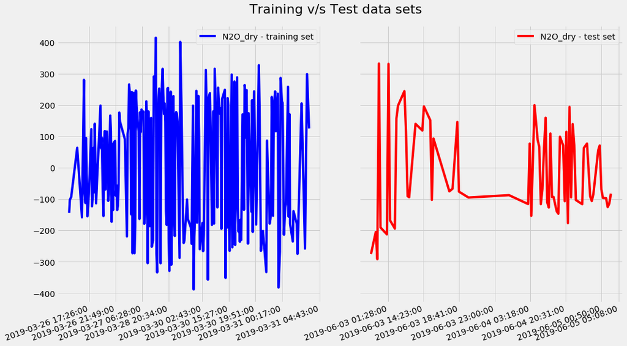

```python
#Visualise the training and test data sets
fig, (axs) = plt.subplots(ncols=2, nrows=1, sharey=True, figsize=(15,8))
fig.suptitle("Training v/s Test data sets", fontsize=22)
fig.tight_layout(pad=3.0)

df_N2Odry = dataframe[dataframe['ghg'] == 'N2O_dry']

axs[0].plot(dataframe_train_N2Odry['Flux'], color='blue')
axs[0].set_xticklabels(dataframe_train_N2Odry.index, rotation=20, ha='right')

axs[1].plot(dataframe_test_N2Odry['Flux'], color='red')
axs[1].set_xticklabels(dataframe_test_N2Odry.index, rotation=20, ha='right')

axs[0].legend(['N2O_dry - training set'])
axs[1].legend(['N2O_dry - test set'])

plt.show()
```

### Remove any outliers from the training datasets -

- seems none
- test data sets hold few outliers

### Check for any seasonal patterns in the gas flux

### Format training data for prophet model using ds and y

```python
dataframe_train_N2Odry
```

```python
dataframe_train_N2Odry = dataframe_train_N2Odry.drop('ghg', axis=1)  #, errors='ignore'

#dataframe_train_N2Odry
```

#### Do the same for the test data set

```python
dataframe_test_N2Odry = dataframe_test_N2Odry.drop('ghg', axis=1)   #, errors='ignore'

#dataframe_test_CO2dry.to_csv('testco2.csv')
```

## Forecasting N2O_dry

#### Display the distribution of the N2O_dry gas flux

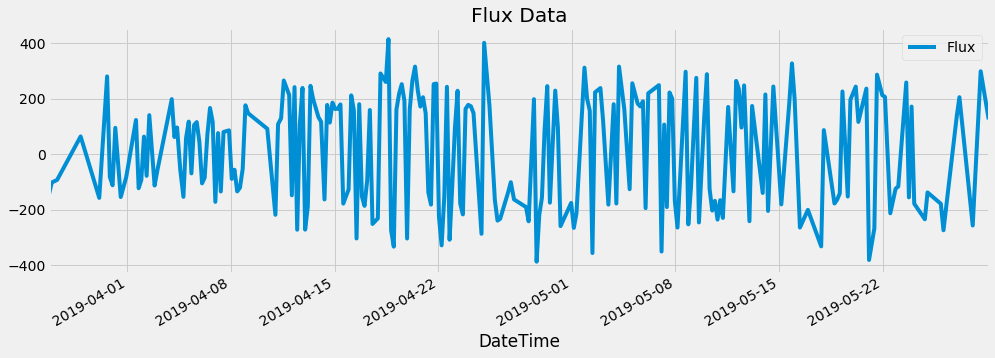

```python
dataframe_train_N2Odry.plot(style='-', figsize=(15,5), title='Flux Data')
```

### ### Visualising gas flux for one particular day

```python
#Choose one particular gas
#Choose one day from the dataset
dataframe_train_N2Odry_hourly = dataframe_train_N2Odry.copy()

df         = DataFrame()
df['date'] = pd.to_datetime(dataframe_train_N2Odry_hourly.index)

start_date = '2019-04-25'
end_date   = '2019-04-26'

df1 = dataframe_train_N2Odry_hourly[((dataframe_train_N2Odry_hourly.index >= start_date) & (dataframe_train_N2Odry_hourly.index < end_date))]

#print(df1)
```

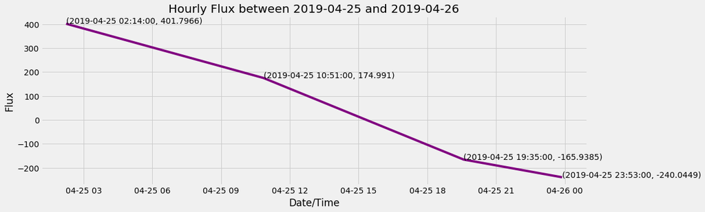

```python
# Create figure and plot space
df2 = df1.reset_index()

fig, ax = plt.subplots(figsize=(15, 5))

# Add x-axis and y-axis
ax.plot(df2['DateTime'],
        df2['Flux'],
        color='purple')

# Set title and labels for axes
ax.set(xlabel="Date/Time",
       ylabel="Flux",
       title="Hourly Flux between "+start_date+" and "+end_date)

#plt.plot(A,B)
for xy in zip(df2['DateTime'], df2['Flux']):
    ax.annotate('(%s, %s)' % xy, xy=xy, textcoords='data')


#plt.grid()
plt.show()
```

##### Note: There is a decrease from early morning till night.

### Visualising gas flux per day of week

```python
days = ["Monday", "Tuesday", "Wednesday", "Thursday", "Friday", "Saturday", "Sunday"]

seriesObj_f = features_target['dayofweek']

df_f = seriesObj_f.to_frame()

#Merge with dataframe

df_all = dataframe.copy()

df_merge_col_all = pd.merge(df_f, df_all, on='DateTime')


df_merge_col_all

for index, row in df_merge_col_all.iterrows():
    row.dayofweek = days[int(row.dayofweek)]  #convert datetime object to string
    df_merge_col_all.loc[index, 'dayofweek'] = row.dayofweek

df_merge_col_n2o = df_merge_col_all[df_merge_col_all['ghg'] == 'N2O_dry']

df_merge_col_n2o.reset_index(drop=True, inplace=True)
#df_merge_col_n2o
```

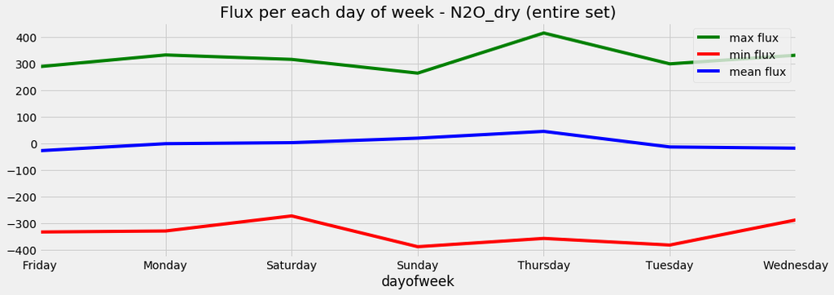

```python
#Plot the training dataset
fig, ax = plt.subplots(figsize=(15, 5))

ax = plt.gca()

df_all = df_merge_col_n2o
df_all.groupby('dayofweek').max().plot(kind='line', ax=ax, color='green')
df_all.groupby('dayofweek').min().plot(kind='line', ax=ax, color='red')
df_all.groupby('dayofweek').mean().plot(kind='line', ax=ax, color='blue')
ax.legend(["max flux", "min flux", "mean flux"])
ax.title.set_text("Flux per each day of week - N2O_dry (entire set)")
plt.show()
```

#### The mean is not a constant line - not ideal for time series forecasting

#### Visualising Test set

```python
days = ["Monday", "Tuesday", "Wednesday", "Thursday", "Friday", "Saturday", "Sunday"]

seriesObj_f = features_target['dayofweek']

df_f = seriesObj_f.to_frame()

#Merge with test dataframe
df_te = dataframe_test_N2Odry.copy()

df_merge_col_1 = pd.merge(df_f, df_te, on='DateTime')

df_merge_col_1

for index, row in df_merge_col_1.iterrows():
    row.dayofweek = days[int(row.dayofweek)]  #convert datetime object to string
    df_merge_col_1.loc[index, 'dayofweek'] = row.dayofweek

df_merge_col_1.reset_index(drop=True, inplace=True)
#df_merge_col_1
```

```python
#Plot the test dataset
fig, ax = plt.subplots(figsize=(15, 5))

ax = plt.gca()

df = df_merge_col_1
#print(df.groupby('dayofweek').sum())
df.groupby('dayofweek').max().plot(kind='line', ax=ax, color='green')
df.groupby('dayofweek').min().plot(kind='line', ax=ax, color='red')
df.groupby('dayofweek').mean().plot(kind='line', ax=ax, color='blue')
ax.legend(["max flux", "min flux", "mean flux"])
ax.title.set_text("Hourly Flux per each day of week - N2O_dry (test set)")
plt.show()
```

[output not shown]

### Generate Simple Prophet Model for N2O_dry gas

```
INFO:numexpr.utils:NumExpr defaulting to 4 threads.
INFO:fbprophet:Disabling yearly seasonality. Run prophet with yearly_seasonality=True to override this.
```

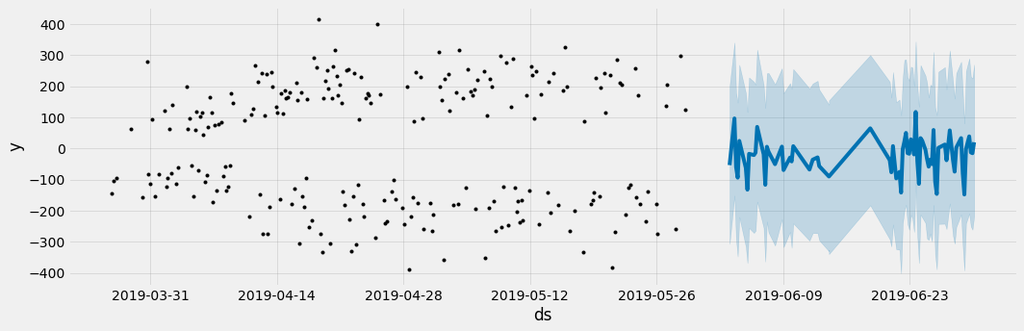

```python
m32 = Prophet()
m32.fit(dataframe_train_N2Odry.reset_index().rename(columns={'DateTime': 'ds', 'Flux': 'y'}))
forecast1_n2o = m32.predict(df=dataframe_test_N2Odry.reset_index().rename(columns={'DateTime': 'ds'}))

# Plot the forecast
f, ax = plt.subplots(1)
f.set_figheight(5)
f.set_figwidth(15)
fig = m32.plot(forecast1_n2o,ax=ax)
plt.show()
```

### Plot the components of the model

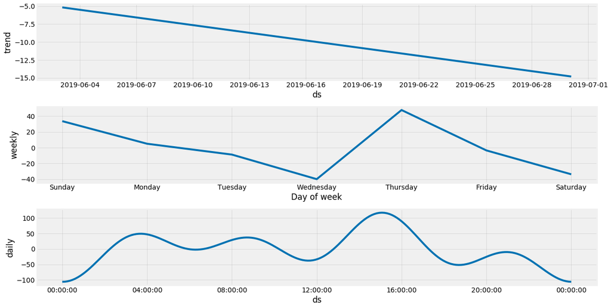

```python
fig = m32.plot_components(forecast1_n2o)
fig.set_figwidth(20)
```

### Compare Actual to Forecasted Simple Model

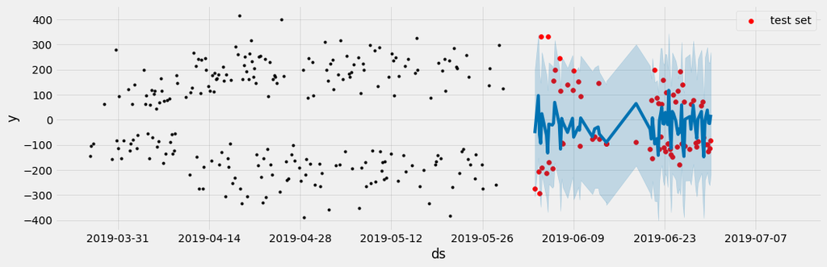

```python
# Plot the forecast with the actuals
f, ax = plt.subplots(1)
f.set_figheight(5)
f.set_figwidth(15)
ax.scatter(dataframe_test_N2Odry.index, dataframe_test_N2Odry['Flux'], color='r', label="test set")
ax.legend()
fig = m32.plot(forecast1_n2o, ax=ax)
```

#### There is a big gap in actual data and forecasted data

### Compare the gas flux in test set and in forecasted set

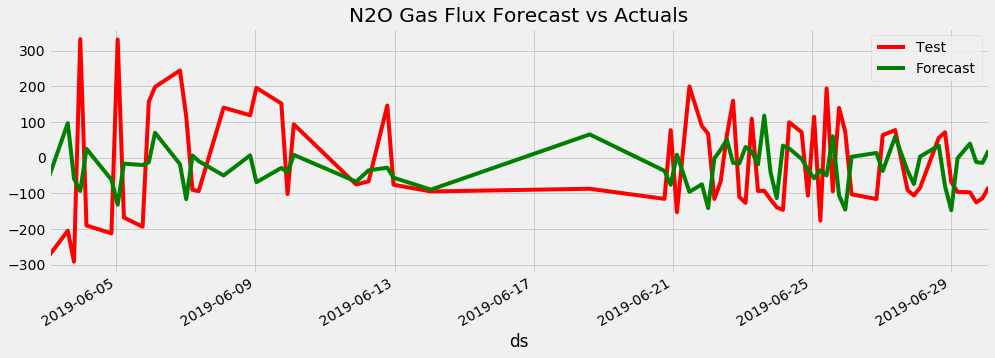

```python
df1=dataframe_test_N2Odry.reset_index().rename(columns={'DateTime': 'ds'})

f, ax = plt.subplots(figsize=(14,5))
f.set_figheight(5)
f.set_figwidth(15)

df1.plot(kind='line', x='ds', y='Flux', color='red', label='Test', ax=ax)
forecast1_n2o.plot(kind='line',x='ds',y='yhat', color='green',label='Forecast', ax=ax)

plt.title('N2O Gas Flux Forecast vs Actuals')
plt.show()
```

#### There is a very big gap between the actual and forecasted sets. No point running forecasts using this model. Need to tune this model. Not saving this model.

### Can we use Interpolation??

```python
dataframe_train_N2Odry
```

| DateTime | Flux |
| --- | --- |
| 2019-03-26 17:26:00 | -144.0262 |
| 2019-03-26 21:49:00 | -102.3469 |
| 2019-03-27 06:28:00 | -93.0909 |
| 2019-03-28 20:34:00 | 63.8219 |
| 2019-03-30 02:43:00 | -157.9453 |
| ... | ... |
| 2019-05-26 23:52:00 | 137.2504 |
| 2019-05-27 04:10:00 | 205.5314 |
| 2019-05-28 01:42:00 | -257.6821 |
| 2019-05-28 14:37:00 | 299.1684 |
| 2019-05-29 03:33:00 | 125.5749 |

232 rows × 1 columns

### There is a big gap in the timestamps - can we use Interpolation here? for instance, can we cover readings for 1 day (03-29th)??

```python
#### Now, we will predict by creating future dataframe next dates of train data.
#make_future_dataframe has include_history = True by default.
#So the prediction will be done for train data as well.
```

### Forecast for next 1 month

```python
#future22       = m32.make_future_dataframe(periods=30, freq='D')
#forecast2_n2o = m32.predict(future22)

## Plot the forecast
#f, ax = plt.subplots(1)
#f.set_figheight(5)
#f.set_figwidth(15)
#fig = m32.plot(forecast2_n2o,ax=ax)
#plt.show()

# Plot the components of the model
#fig1 = m32.plot_components(forecast2_n2o)
#fig1.set_figwidth(20)
```

### Actuals v/s Forecast (simple model)

```python
#df = df_N2Odry.reset_index().rename(columns={'DateTime': 'ds', 'Flux': 'y'})

## Plot the forecast with the actuals
#f1, ax = plt.subplots(1)
#f1.set_figheight(5)
#f1.set_figwidth(15)
#ax.scatter(df.ds, df['y'], color='r', label="test set")
#ax.legend()

#fig2 = m32.plot(forecast2_n2o, ax=ax)
```

### Plot the forecast with the actuals for first week of June

```python
#f, ax = plt.subplots(1)
#f.set_figheight(5)
#f.set_figwidth(15)
#ax.scatter(df.ds, df['y'], color='r', label="test set")
#ax.legend()


#fig = m32.plot(forecast1_n2o, ax=ax)

#ax.set_xlim([datetime.date(2019, 6, 1), datetime.date(2019, 6, 7)])
#ax.set_ylim(None, None)

#plot = plt.suptitle('First Week of June Forecast vs Actuals')
```

### Measure the performance of the model

```python
def mean_absolute_percentage_error(y_true, y_pred):
    y_true, y_pred = np.array(y_true), np.array(y_pred)
    return np.mean(np.abs((y_true - y_pred) / y_true)) * 100
```

```python
mape = mean_absolute_percentage_error(dataframe_test_N2Odry['Flux'],forecast1_n2o['yhat'])
print("MAPE",round(mape,4))
```

```
MAPE 106.6011
```

### Cross Validation using the simple model

```python
#horizon = how many days are we going to make forecast
#period  = space between 2 or more training periods (normally 0.5 * horizon)
#initial = size of training period (normally 3* horizon)

df_cv = cross_validation(m32, initial='42 days', period='7 days', horizon = '14 days')
df_p  = performance_metrics(df_cv)
df_p
```

```
INFO:fbprophet:Making 2 forecasts with cutoffs between 2019-05-08 03:33:00 and 2019-05-15 03:33:00
```

|  | horizon | mse | rmse | mae | mape | coverage |
| --- | --- | --- | --- | --- | --- | --- |
| 0 | 1 days 06:14:00 | 63545.609034 | 252.082544 | 232.483057 | 1.008519 | 0.500 |
| 1 | 1 days 06:20:00 | 61180.241700 | 247.346400 | 226.512637 | 0.934620 | 0.500 |
| 2 | 1 days 10:38:00 | 77945.230543 | 279.186731 | 262.217437 | 1.064215 | 0.375 |
| 3 | 1 days 19:09:00 | 72847.328950 | 269.902443 | 250.362267 | 1.058105 | 0.500 |
| 4 | 1 days 19:15:00 | 67704.603260 | 260.201082 | 239.310549 | 1.127408 | 0.625 |
| 5 | 1 days 23:33:00 | 63531.561751 | 252.054680 | 231.701144 | 1.082810 | 0.625 |
| 6 | 2 days 03:51:00 | 62031.872846 | 249.061986 | 226.398507 | 1.101082 | 0.625 |
| 7 | 2 days 08:10:00 | 63195.723737 | 251.387597 | 230.446371 | 1.067880 | 0.625 |
| 8 | 2 days 12:28:00 | 47487.297097 | 217.915803 | 205.166195 | 1.029140 | 0.750 |
| 9 | 2 days 16:41:00 | 57305.752743 | 239.386200 | 224.639399 | 1.073925 | 0.625 |
| 10 | 2 days 16:46:00 | 47057.341027 | 216.927041 | 208.208755 | 1.012724 | 0.750 |
| 11 | 2 days 20:59:00 | 46505.094055 | 215.650398 | 206.490655 | 1.130393 | 0.750 |
| 12 | 2 days 21:04:00 | 43134.404213 | 207.688238 | 194.492481 | 1.024925 | 0.750 |
| 13 | 3 days 01:23:00 | 44964.922206 | 212.049339 | 198.040579 | 1.067038 | 0.750 |
| 14 | 3 days 09:59:00 | 43714.439670 | 209.079984 | 191.348582 | 0.995516 | 0.750 |
| 15 | 3 days 14:12:00 | 50403.047765 | 224.506231 | 206.509011 | 1.094636 | 0.625 |
| 16 | 3 days 18:31:00 | 50450.404831 | 224.611676 | 206.621757 | 1.099255 | 0.625 |
| 17 | 3 days 18:36:00 | 39802.377697 | 199.505333 | 184.620884 | 1.118797 | 0.750 |
| 18 | 3 days 22:49:00 | 41424.392998 | 203.529833 | 187.755981 | 1.228082 | 0.625 |
| 19 | 3 days 22:54:00 | 43475.740049 | 208.508369 | 193.550136 | 1.100965 | 0.625 |
| 20 | 4 days 03:08:00 | 46076.542750 | 214.654473 | 203.408551 | 1.126117 | 0.625 |
| 21 | 4 days 03:13:00 | 43173.155251 | 207.781508 | 197.574051 | 1.097998 | 0.750 |
| 22 | 4 days 07:31:00 | 44058.583783 | 209.901367 | 202.661873 | 1.188855 | 0.750 |
| 23 | 4 days 11:44:00 | 44539.036422 | 211.042736 | 203.505920 | 1.226663 | 0.750 |
| 24 | 4 days 11:49:00 | 43086.856409 | 207.573737 | 199.794203 | 1.157724 | 0.750 |
| 25 | 4 days 16:02:00 | 44049.888344 | 209.880653 | 202.701607 | 1.127026 | 0.750 |
| 26 | 4 days 20:27:00 | 36388.775455 | 190.758422 | 182.647413 | 0.944740 | 0.875 |
| 27 | 5 days 00:39:00 | 35761.727270 | 189.107713 | 181.028987 | 0.946024 | 0.875 |
| 28 | 5 days 00:45:00 | 35513.719192 | 188.450840 | 180.292603 | 0.970320 | 0.875 |
| 29 | 5 days 04:57:00 | 29453.302958 | 171.619646 | 158.174660 | 0.902934 | 0.875 |
| 30 | 5 days 17:52:00 | 34277.643398 | 185.142225 | 172.738904 | 0.881499 | 0.875 |
| 31 | 5 days 17:58:00 | 26300.416567 | 162.174032 | 154.024514 | 0.769747 | 1.000 |
| 32 | 5 days 22:11:00 | 43653.107891 | 208.933262 | 183.193566 | 0.814157 | 0.875 |
| 33 | 5 days 22:16:00 | 46603.797596 | 215.879127 | 190.358664 | 0.837545 | 0.875 |
| 34 | 6 days 02:35:00 | 48629.694615 | 220.521415 | 197.605381 | 0.883220 | 0.875 |
| 35 | 6 days 06:48:00 | 56540.732168 | 237.782952 | 213.400414 | 0.933476 | 0.750 |
| 36 | 6 days 11:06:00 | 58109.945836 | 241.060046 | 217.696463 | 0.901566 | 0.750 |
| 37 | 6 days 11:11:00 | 63144.970899 | 251.286631 | 237.440581 | 0.955118 | 0.750 |
| 38 | 6 days 19:43:00 | 70324.586870 | 265.187833 | 250.450862 | 1.029682 | 0.625 |
| 39 | 7 days 00:01:00 | 71032.571573 | 266.519364 | 252.845124 | 1.001572 | 0.625 |
| 40 | 7 days 00:06:00 | 53234.681865 | 230.726422 | 222.409192 | 0.983687 | 0.750 |
| 41 | 7 days 08:38:00 | 51699.473573 | 227.375182 | 218.930398 | 0.968550 | 0.750 |
| 42 | 7 days 13:01:00 | 50977.223963 | 225.781363 | 216.669460 | 0.966954 | 0.750 |
| 43 | 7 days 17:15:00 | 42901.777464 | 207.127443 | 200.431216 | 1.004878 | 0.875 |
| 44 | 7 days 17:20:00 | 47696.491226 | 218.395264 | 210.428249 | 1.024620 | 0.750 |
| 45 | 7 days 21:34:00 | 45387.341725 | 213.043051 | 204.048068 | 1.085240 | 0.750 |
| 46 | 7 days 21:38:00 | 37077.230623 | 192.554487 | 188.387509 | 1.019668 | 0.875 |
| 47 | 8 days 06:14:00 | 50688.291480 | 225.140604 | 214.410542 | 1.096849 | 0.750 |
| 48 | 8 days 10:29:00 | 48464.330588 | 220.146157 | 206.383627 | 1.030668 | 0.750 |
| 49 | 8 days 14:48:00 | 49629.527341 | 222.776855 | 209.062807 | 1.092361 | 0.750 |
| 50 | 8 days 19:06:00 | 51568.333958 | 227.086622 | 214.663611 | 1.133418 | 0.750 |
| 51 | 8 days 19:09:00 | 50130.593047 | 223.898622 | 210.344103 | 1.041943 | 0.750 |
| 52 | 8 days 23:25:00 | 49580.383160 | 222.666529 | 209.346642 | 1.125029 | 0.750 |
| 53 | 9 days 16:38:00 | 53718.492086 | 231.772501 | 219.829570 | 1.085885 | 0.750 |
| 54 | 9 days 16:41:00 | 62793.762126 | 250.586835 | 236.640524 | 1.085130 | 0.625 |
| 55 | 9 days 20:56:00 | 46801.690159 | 216.336983 | 200.405531 | 0.981247 | 0.750 |
| 56 | 9 days 20:59:00 | 48930.220570 | 221.201764 | 208.150962 | 1.172584 | 0.750 |
| 57 | 10 days 14:12:00 | 48015.382595 | 219.124126 | 206.070349 | 1.138266 | 0.750 |
| 58 | 10 days 18:29:00 | 50097.307502 | 223.824278 | 210.915076 | 1.159327 | 0.750 |
| 59 | 10 days 18:31:00 | 51599.533327 | 227.155307 | 215.409433 | 1.207396 | 0.750 |
| 60 | 10 days 22:47:00 | 63390.184474 | 251.774074 | 232.699098 | 1.204026 | 0.750 |
| 61 | 10 days 22:49:00 | 61114.588258 | 247.213649 | 227.491156 | 1.251348 | 0.750 |
| 62 | 11 days 03:08:00 | 53047.836205 | 230.321159 | 213.056724 | 1.247257 | 0.875 |
| 63 | 11 days 11:44:00 | 58291.796108 | 241.436940 | 230.886947 | 1.357003 | 0.875 |
| 64 | 11 days 16:02:00 | 61315.829455 | 247.620333 | 238.492328 | 1.260019 | 0.875 |
| 65 | 11 days 20:19:00 | 61680.388840 | 248.355368 | 239.340463 | 1.310491 | 0.875 |
| 66 | 12 days 00:37:00 | 57278.139361 | 239.328518 | 227.583271 | 1.232355 | 0.875 |
| 67 | 12 days 00:39:00 | 59977.701198 | 244.903453 | 233.988749 | 1.212744 | 0.750 |
| 68 | 12 days 04:57:00 | 39927.877626 | 199.819613 | 193.769071 | 1.121219 | 0.875 |
| 69 | 12 days 17:52:00 | 42153.395128 | 205.312920 | 198.872196 | 1.072756 | 0.750 |
| 70 | 12 days 22:09:00 | 46864.385537 | 216.481837 | 207.995548 | 1.093218 | 0.625 |
| 71 | 12 days 22:11:00 | 56502.411348 | 237.702359 | 224.856109 | 1.030569 | 0.500 |
| 72 | 13 days 06:48:00 | 57465.765241 | 239.720181 | 226.885521 | 0.999233 | 0.375 |
| 73 | 13 days 11:04:00 | 56802.570073 | 238.332898 | 225.321794 | 0.886396 | 0.375 |
| 74 | 13 days 11:06:00 | 62422.763459 | 249.845479 | 239.572543 | 0.911879 | 0.250 |
| 75 | 13 days 19:43:00 | 72923.830705 | 270.044127 | 256.778006 | 1.010721 | 0.250 |
| 76 | 14 days 00:00:00 | 72538.166750 | 269.329105 | 254.323312 | 0.984158 | 0.250 |

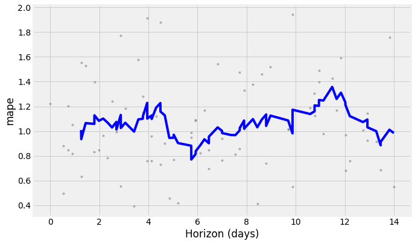

```python
fig3 = plot_cross_validation_metric(df_cv, metric='mape')
```

### Generate Model with Tuned Parameters (using HyperParameter Tuning)

### Hyperparameter Tuning

- do hyperparameter tuning using ParameterGrid from sklearn:
  - Hyper Parameters: (as advised by fbProphet authors to be tunable)
    - changepoint_prior_scale
    - seasonality_prior_scale
    - seasonality_mode: additive/multiplicative seasonality (in this case, the seasonality looks more additive)
    - uncertainty intervals - mcmc (bayesian sampling) (Not Tunable)
- add changepoints, add holiday effect
- do forecast - hourly, daily, weekly
- add met data

### Prophet Model Tuning

```python
params_grid = {
                'seasonality_prior_scale':[0.01, 0.05, 0.1, 0.2, 0.3, 0.4, 0.5, 2, 4, 6, 8, 10], # range [0.01, 10]
                'changepoint_prior_scale':[0.05, 0.1, 0.2, 0.3, 0.4, 0.5],    #range [0.001, 0.5]
                'n_changepoints'         :[25,75,125]
              }

grid = ParameterGrid(params_grid)
cnt = 0
for p in grid:
    cnt = cnt+1

print('Total Possible Models',cnt)
```

```
Total Possible Models 216
```

```python
def get_dates(df, start_date, end_date):

    start_date = pd.to_datetime(start_date) #, utc= True)
    end_date   = pd.to_datetime(end_date) #, utc= True)

    series_dates = df.copy()
    series_dates = series_dates.reset_index().drop('ghg', axis=1)
    series_dates

    mask = (series_dates['DateTime'] > start_date) & (series_dates['DateTime'] < end_date)
    filtered_df = series_dates.loc[mask]

    return filtered_df
```

```python
start_date = '2019-05-29'
end_date   = '2019-06-29'

#actual     = get_dates(dataf, start_date, end_date)  #30 days forecast - to retrieve the dates

model_parameters = pd.DataFrame(columns = ['MAPE', 'Parameters'])
for p in grid:
    test = pd.DataFrame()
    print(p)
    #print('\n')
    random.seed(0)

    #weekly_seasonality=False,
    #daily_seasonality=True,
    #yearly_seasonality=False,

    tuned_model2 = Prophet(changepoint_prior_scale=p['changepoint_prior_scale'],
                          seasonality_prior_scale=p['seasonality_prior_scale'],
                          n_changepoints=p['n_changepoints'],
                          interval_width=0.95
                         )

    tuned_model2.fit(dataframe_train_N2Odry.reset_index().rename(columns={'DateTime': 'ds', 'Flux': 'y'}))

    #by default, include_history=true, it means it will include train data as well
    #future3       = tuned_model.make_future_dataframe(periods=30, freq='D', include_history = False)
    future32 = tuned_model2.predict(df=dataframe_test_N2Odry.reset_index().rename(columns={'DateTime': 'ds'}))

    #Calculate the performance metric
    MAPE = mean_absolute_percentage_error(y_true=dataframe_test_N2Odry['Flux'], y_pred=future32['yhat'])
    print('Mean Absolute Percentage Error (MAPE)-------------------', MAPE)
    model_parameters = model_parameters.append({'MAPE': MAPE, 'Parameters': p}, ignore_index=True)
    print('\n')
```

#### Print the dataframe containing the parameter combinations and the performance metric result

```python
parameters = model_parameters.sort_values(by=['MAPE'])
parameters = parameters.reset_index(drop=True)

pd.set_option('display.max_colwidth', -1)
pd.set_option('display.max_rows', None)
parameters
```

|  | MAPE | Parameters |
| --- | --- | --- |
| 0 | 96.953863 | {'changepoint_prior_scale': 0.5, 'n_changepoints': 125, 'seasonality_prior_scale': 0.01} |
| 1 | 97.045467 | {'changepoint_prior_scale': 0.5, 'n_changepoints': 75, 'seasonality_prior_scale': 0.01} |
| 2 | 97.615187 | {'changepoint_prior_scale': 0.4, 'n_changepoints': 125, 'seasonality_prior_scale': 0.01} |
| 3 | 97.706399 | {'changepoint_prior_scale': 0.5, 'n_changepoints': 25, 'seasonality_prior_scale': 0.01} |
| 4 | 98.228604 | {'changepoint_prior_scale': 0.4, 'n_changepoints': 25, 'seasonality_prior_scale': 0.01} |
| 5 | 98.911406 | {'changepoint_prior_scale': 0.4, 'n_changepoints': 75, 'seasonality_prior_scale': 0.01} |
| 6 | 99.306575 | {'changepoint_prior_scale': 0.3, 'n_changepoints': 25, 'seasonality_prior_scale': 0.01} |
| 7 | 99.429705 | {'changepoint_prior_scale': 0.2, 'n_changepoints': 75, 'seasonality_prior_scale': 0.01} |
| 8 | 99.519774 | {'changepoint_prior_scale': 0.3, 'n_changepoints': 125, 'seasonality_prior_scale': 0.01} |
| 9 | 99.649725 | {'changepoint_prior_scale': 0.3, 'n_changepoints': 75, 'seasonality_prior_scale': 0.01} |
| 10 | 100.200992 | {'changepoint_prior_scale': 0.05, 'n_changepoints': 125, 'seasonality_prior_scale': 0.01} |
| 11 | 100.413314 | {'changepoint_prior_scale': 0.2, 'n_changepoints': 25, 'seasonality_prior_scale': 0.01} |
| 12 | 100.833185 | {'changepoint_prior_scale': 0.1, 'n_changepoints': 75, 'seasonality_prior_scale': 0.01} |
| 13 | 101.002972 | {'changepoint_prior_scale': 0.05, 'n_changepoints': 25, 'seasonality_prior_scale': 0.01} |
| 14 | 101.102843 | {'changepoint_prior_scale': 0.2, 'n_changepoints': 125, 'seasonality_prior_scale': 0.01} |
| 15 | 101.249385 | {'changepoint_prior_scale': 0.5, 'n_changepoints': 125, 'seasonality_prior_scale': 0.05} |
| 16 | 101.456331 | {'changepoint_prior_scale': 0.5, 'n_changepoints': 75, 'seasonality_prior_scale': 0.05} |
| 17 | 101.820764 | {'changepoint_prior_scale': 0.5, 'n_changepoints': 25, 'seasonality_prior_scale': 0.05} |
| 18 | 102.145887 | {'changepoint_prior_scale': 0.1, 'n_changepoints': 25, 'seasonality_prior_scale': 0.01} |
| 19 | 102.342429 | {'changepoint_prior_scale': 0.4, 'n_changepoints': 25, 'seasonality_prior_scale': 0.05} |
| 20 | 102.494560 | {'changepoint_prior_scale': 0.4, 'n_changepoints': 125, 'seasonality_prior_scale': 0.05} |
| 21 | 102.500877 | {'changepoint_prior_scale': 0.1, 'n_changepoints': 125, 'seasonality_prior_scale': 0.01} |
| 22 | 102.577327 | {'changepoint_prior_scale': 0.05, 'n_changepoints': 125, 'seasonality_prior_scale': 0.5} |
| 23 | 102.601680 | {'changepoint_prior_scale': 0.4, 'n_changepoints': 75, 'seasonality_prior_scale': 0.05} |
| 24 | 102.829981 | {'changepoint_prior_scale': 0.3, 'n_changepoints': 25, 'seasonality_prior_scale': 0.05} |
| 25 | 103.005078 | {'changepoint_prior_scale': 0.3, 'n_changepoints': 75, 'seasonality_prior_scale': 0.05} |
| 26 | 103.071072 | {'changepoint_prior_scale': 0.3, 'n_changepoints': 125, 'seasonality_prior_scale': 0.05} |
| 27 | 103.302597 | {'changepoint_prior_scale': 0.2, 'n_changepoints': 75, 'seasonality_prior_scale': 0.05} |
| 28 | 103.468146 | {'changepoint_prior_scale': 0.2, 'n_changepoints': 25, 'seasonality_prior_scale': 0.05} |
| 29 | 103.500132 | {'changepoint_prior_scale': 0.05, 'n_changepoints': 125, 'seasonality_prior_scale': 0.05} |

[output cut: 186 more lines]

#### Print the parameter combination for the best model (i.e. with least MAPE value)

```python
parameters['Parameters'][0]
```

```
{'changepoint_prior_scale': 0.5,
 'n_changepoints': 125,
 'seasonality_prior_scale': 0.01}
```

#### Set up the final model with the above parameters

{'changepoint_prior_scale': 0.5, 'n_changepoints': 125, 'seasonality_prior_scale': 0.01}

```
INFO:fbprophet:Disabling yearly seasonality. Run prophet with yearly_seasonality=True to override this.
```

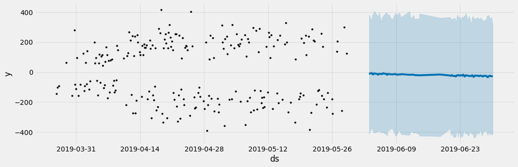

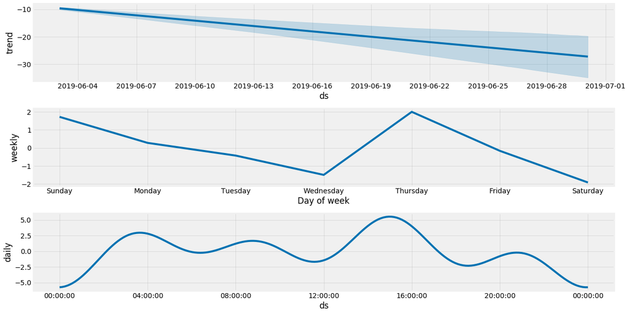

```python
final_model2 = Prophet(changepoint_prior_scale=0.5,
                      seasonality_prior_scale=0.01,
                      n_changepoints= 125,
                      interval_width=0.95)

final_model2.fit(dataframe_train_N2Odry.reset_index().rename(columns={'DateTime': 'ds', 'Flux': 'y'}))

forecast_tunedmodel_v111 = final_model2.predict(df=dataframe_test_N2Odry.reset_index().rename(columns={'DateTime': 'ds'}))

# Plot the forecast
f, ax = plt.subplots(1)
f.set_figheight(5)
f.set_figwidth(15)
fig = final_model2.plot(forecast_tunedmodel_v111,ax=ax)
plt.show()

# Plot the components of the model
fig1 = final_model2.plot_components(forecast_tunedmodel_v111)
fig1.set_figwidth(20)
```

```python
mape = mean_absolute_percentage_error(dataframe_test_N2Odry['Flux'],forecast_tunedmodel_v111['yhat'])
print("MAPE",round(mape,4))
```

```
MAPE 96.9539
```

### Use Cross Validation for tuned_model

```python
#horizon = how many days are we going to make forecast
#period  = space between 2 or more training periods (normally 0.5 * horizon)
#initial = size of training period (normally 3* horizon)

df_cv111 = cross_validation(final_model2, initial='42 days', period='7 days', horizon = '14 days')
df_p111 = performance_metrics(df_cv111)
df_p111
```

```
INFO:fbprophet:Making 2 forecasts with cutoffs between 2019-05-08 03:33:00 and 2019-05-15 03:33:00
```

|  | horizon | mse | rmse | mae | mape | coverage |
| --- | --- | --- | --- | --- | --- | --- |
| 0 | 1 days 06:14:00 | 56717.989657 | 238.155390 | 230.491049 | 1.016501 | 1.000 |
| 1 | 1 days 06:20:00 | 60137.277737 | 245.229031 | 238.147670 | 0.998995 | 1.000 |
| 2 | 1 days 10:38:00 | 65417.857777 | 255.769149 | 250.044951 | 1.018433 | 1.000 |
| 3 | 1 days 19:09:00 | 61022.043935 | 247.026403 | 241.001156 | 1.029675 | 1.000 |
| 4 | 1 days 19:15:00 | 50281.445589 | 224.235246 | 216.423391 | 1.020347 | 1.000 |
| 5 | 1 days 23:33:00 | 50000.387684 | 223.607665 | 215.904753 | 1.002205 | 1.000 |
| 6 | 2 days 03:51:00 | 48036.823608 | 219.173045 | 209.977955 | 1.025467 | 1.000 |
| 7 | 2 days 08:10:00 | 51657.001931 | 227.281768 | 220.077637 | 1.017284 | 1.000 |
| 8 | 2 days 12:28:00 | 46274.515616 | 215.115122 | 208.557862 | 1.024494 | 1.000 |
| 9 | 2 days 16:41:00 | 52698.346451 | 229.561204 | 219.366856 | 1.036990 | 1.000 |
| 10 | 2 days 16:46:00 | 51727.561515 | 227.436940 | 217.514958 | 1.035097 | 1.000 |
| 11 | 2 days 20:59:00 | 47242.627693 | 217.353693 | 202.048352 | 1.026406 | 1.000 |
| 12 | 2 days 21:04:00 | 49506.522609 | 222.500613 | 209.578926 | 1.050446 | 1.000 |
| 13 | 3 days 01:23:00 | 48280.068372 | 219.727259 | 207.215158 | 1.069649 | 1.000 |
| 14 | 3 days 09:59:00 | 48503.521576 | 220.235151 | 207.985549 | 1.036100 | 1.000 |
| 15 | 3 days 14:12:00 | 46937.905654 | 216.651577 | 204.153778 | 1.033902 | 1.000 |
| 16 | 3 days 18:31:00 | 46292.153150 | 215.156113 | 202.363804 | 1.026534 | 1.000 |
| 17 | 3 days 18:36:00 | 34704.625965 | 186.291776 | 178.839877 | 1.040506 | 1.000 |
| 18 | 3 days 22:49:00 | 29604.746062 | 172.060298 | 166.396562 | 1.042776 | 1.000 |
| 19 | 3 days 22:54:00 | 36156.169194 | 190.147756 | 186.451165 | 1.038130 | 1.000 |
| 20 | 4 days 03:08:00 | 37967.424325 | 194.852314 | 191.009623 | 1.022333 | 1.000 |
| 21 | 4 days 03:13:00 | 36081.971356 | 189.952550 | 186.978246 | 1.002137 | 1.000 |
| 22 | 4 days 07:31:00 | 34115.511171 | 184.703847 | 178.310591 | 0.996002 | 1.000 |
| 23 | 4 days 11:44:00 | 33096.380045 | 181.924105 | 175.439518 | 0.998955 | 1.000 |
| 24 | 4 days 11:49:00 | 35829.542077 | 189.286931 | 182.255864 | 0.982009 | 1.000 |
| 25 | 4 days 16:02:00 | 37404.543311 | 193.402542 | 186.870441 | 0.960527 | 1.000 |
| 26 | 4 days 20:27:00 | 42443.783966 | 206.018892 | 199.194491 | 0.954530 | 1.000 |
| 27 | 5 days 00:39:00 | 41905.478885 | 204.708278 | 198.068586 | 0.959549 | 1.000 |
| 28 | 5 days 00:45:00 | 39042.838857 | 197.592608 | 190.379383 | 0.951438 | 1.000 |
| 29 | 5 days 04:57:00 | 34554.189070 | 185.887571 | 176.565163 | 0.951229 | 1.000 |
| 30 | 5 days 17:52:00 | 40395.186936 | 200.985539 | 195.478120 | 0.970298 | 1.000 |
| 31 | 5 days 17:58:00 | 40060.723792 | 200.151752 | 194.444970 | 0.975466 | 1.000 |
| 32 | 5 days 22:11:00 | 52547.521002 | 229.232461 | 214.672349 | 0.988169 | 0.875 |
| 33 | 5 days 22:16:00 | 52987.845170 | 230.190889 | 215.809194 | 0.982911 | 0.875 |
| 34 | 6 days 02:35:00 | 51065.215015 | 225.976138 | 211.762522 | 0.986852 | 0.875 |
| 35 | 6 days 06:48:00 | 53694.754036 | 231.721285 | 216.915215 | 0.995223 | 0.875 |
| 36 | 6 days 11:06:00 | 60256.015097 | 245.471007 | 232.095512 | 1.004098 | 0.875 |
| 37 | 6 days 11:11:00 | 65135.757071 | 255.217078 | 246.793528 | 1.003957 | 0.875 |
| 38 | 6 days 19:43:00 | 64197.697037 | 253.372645 | 244.677001 | 1.007711 | 0.875 |
| 39 | 7 days 00:01:00 | 66005.179060 | 256.914731 | 249.753123 | 0.986988 | 0.875 |
| 40 | 7 days 00:06:00 | 51993.567535 | 228.020980 | 225.954164 | 0.996809 | 1.000 |
| 41 | 7 days 08:38:00 | 53057.850892 | 230.342899 | 228.507372 | 1.009733 | 1.000 |
| 42 | 7 days 13:01:00 | 50414.844119 | 224.532501 | 221.700509 | 0.986985 | 1.000 |
| 43 | 7 days 17:15:00 | 43100.847798 | 207.607437 | 203.783054 | 0.991157 | 1.000 |
| 44 | 7 days 17:20:00 | 45337.934496 | 212.927064 | 207.611753 | 0.987907 | 1.000 |
| 45 | 7 days 21:34:00 | 40916.833974 | 202.279099 | 194.904846 | 1.004585 | 1.000 |
| 46 | 7 days 21:38:00 | 39347.694960 | 198.362534 | 190.926810 | 0.993129 | 1.000 |
| 47 | 8 days 06:14:00 | 44740.354452 | 211.519159 | 202.033398 | 1.008600 | 1.000 |
| 48 | 8 days 10:29:00 | 47371.198661 | 217.649256 | 207.937571 | 0.990404 | 1.000 |
| 49 | 8 days 14:48:00 | 44728.025598 | 211.490013 | 201.016426 | 0.993172 | 1.000 |
| 50 | 8 days 19:06:00 | 44810.081593 | 211.683919 | 201.260796 | 1.003937 | 1.000 |
| 51 | 8 days 19:09:00 | 48472.040983 | 220.163669 | 211.758191 | 1.005653 | 1.000 |
| 52 | 8 days 23:25:00 | 41094.606135 | 202.718046 | 196.881681 | 1.019943 | 1.000 |
| 53 | 9 days 16:38:00 | 46373.919925 | 215.346047 | 211.436716 | 1.015512 | 1.000 |
| 54 | 9 days 16:41:00 | 57739.286891 | 240.290006 | 232.753635 | 1.033691 | 1.000 |
| 55 | 9 days 20:56:00 | 49831.755948 | 223.230276 | 214.184093 | 1.023669 | 1.000 |
| 56 | 9 days 20:59:00 | 42893.688749 | 207.107916 | 192.408891 | 1.008686 | 1.000 |
| 57 | 10 days 14:12:00 | 44463.130389 | 210.862824 | 196.752984 | 1.016858 | 1.000 |
| 58 | 10 days 18:29:00 | 45181.692371 | 212.559856 | 198.782933 | 1.023024 | 1.000 |
| 59 | 10 days 18:31:00 | 43521.421053 | 208.617883 | 194.627931 | 1.027830 | 1.000 |
| 60 | 10 days 22:47:00 | 49260.417715 | 221.946880 | 206.740604 | 1.025951 | 1.000 |
| 61 | 10 days 22:49:00 | 45392.872220 | 213.056031 | 197.125409 | 1.042238 | 1.000 |
| 62 | 11 days 03:08:00 | 35312.222749 | 187.915467 | 179.110728 | 1.024922 | 1.000 |
| 63 | 11 days 11:44:00 | 36698.815886 | 191.569350 | 183.544338 | 1.041647 | 1.000 |
| 64 | 11 days 16:02:00 | 40051.559070 | 200.128856 | 196.891392 | 1.051372 | 1.000 |
| 65 | 11 days 20:19:00 | 37557.519564 | 193.797625 | 189.486119 | 1.038881 | 1.000 |
| 66 | 12 days 00:37:00 | 38230.567340 | 195.526385 | 191.237784 | 1.030862 | 1.000 |
| 67 | 12 days 00:39:00 | 40350.252435 | 200.873723 | 196.434175 | 1.006772 | 1.000 |
| 68 | 12 days 04:57:00 | 31343.023534 | 177.039610 | 172.863488 | 0.981032 | 1.000 |
| 69 | 12 days 17:52:00 | 33985.757391 | 184.352264 | 179.802952 | 0.952733 | 1.000 |
| 70 | 12 days 22:09:00 | 37177.224083 | 192.813962 | 186.596091 | 0.965093 | 1.000 |
| 71 | 12 days 22:11:00 | 53338.933609 | 230.952232 | 214.771232 | 0.953707 | 0.875 |
| 72 | 13 days 06:48:00 | 59530.368363 | 243.988459 | 228.097966 | 0.973039 | 0.875 |
| 73 | 13 days 11:04:00 | 67789.788620 | 260.364722 | 247.266036 | 0.968705 | 0.875 |
| 74 | 13 days 11:06:00 | 71746.736275 | 267.855812 | 255.754528 | 0.963937 | 0.875 |
| 75 | 13 days 19:43:00 | 70508.237352 | 265.533872 | 252.848897 | 0.967269 | 0.875 |
| 76 | 14 days 00:00:00 | 71142.949327 | 266.726357 | 255.774191 | 0.982881 | 0.875 |

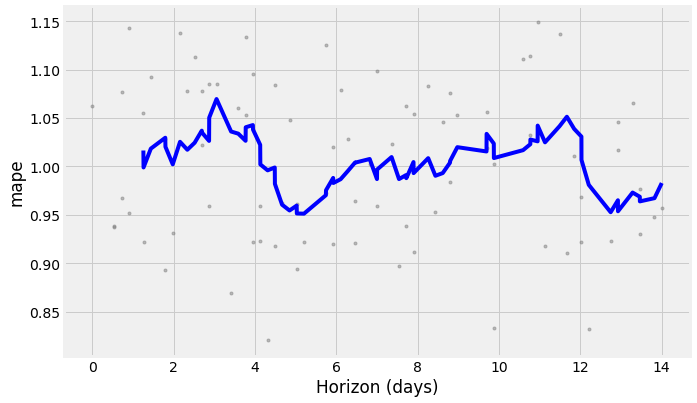

```python
fig3 = plot_cross_validation_metric(df_cv111, metric='mape')
```

### Compare Forecast vs Actual using tuned model

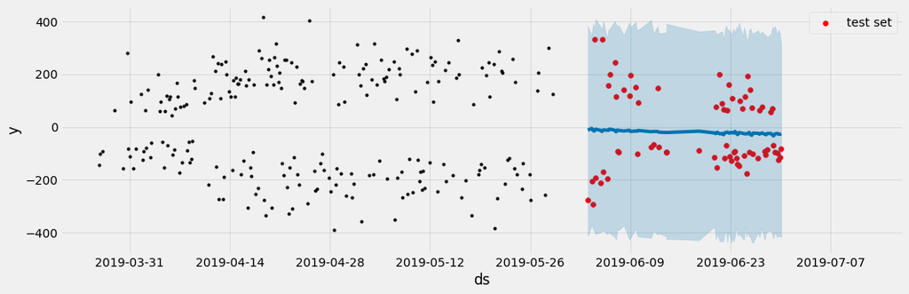

```python
# Plot the forecast with the actuals
f, ax = plt.subplots(1)
f.set_figheight(5)
f.set_figwidth(15)
ax.scatter(dataframe_test_N2Odry.index, dataframe_test_N2Odry['Flux'], color='r', label="test set")
ax.legend()
fig = final_model2.plot(forecast_tunedmodel_v111, ax=ax)
```

### Compare the gas flux in test set and in forecasted set (using finalmodel2)

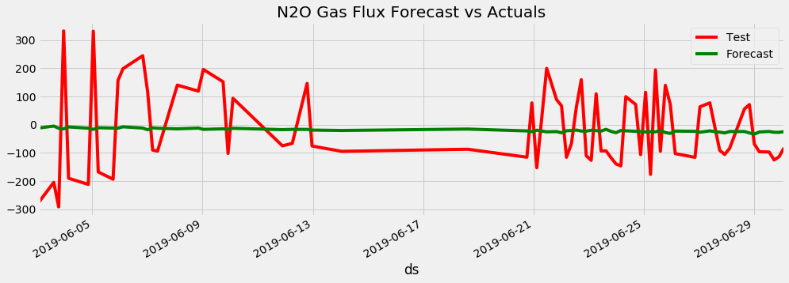

```python
df1=dataframe_test_N2Odry.reset_index().rename(columns={'DateTime': 'ds'})

f, ax = plt.subplots(figsize=(14,5))
f.set_figheight(5)
f.set_figwidth(15)

df1.plot(kind='line', x='ds', y='Flux', color='red', label='Test', ax=ax)
forecast_tunedmodel_v111.plot(kind='line',x='ds',y='yhat', color='green',label='Forecast', ax=ax)

plt.title('N2O Gas Flux Forecast vs Actuals')
plt.show()
```

#### We can see from the above plot, it is a very inaccurate plot (hence model).

#### Forecast for next 48 hours

```python
#future_48h2     = final_model2.make_future_dataframe(periods=48, freq='H', include_history = False)
#forecast_hours2 = final_model2.predict(future_48h1)

## Plot the forecast
#f, ax = plt.subplots(1)
#f.set_figheight(5)
#f.set_figwidth(15)
#fig = final_model2.plot(forecast_hours2,ax=ax)
#plt.show()

## Plot the components of the model
#fig1 = final_model2.plot_components(forecast_hours2)
#fig1.set_figwidth(20)
```

#### Forecast for next 2 weeks

```python
#future_2wks2    = final_model2.make_future_dataframe(periods=14, freq='D', include_history = False)
#forecast_2wks2  = final_model2.predict(future_2wks2)

## Plot the forecast
#f, ax = plt.subplots(1)
#f.set_figheight(5)
#f.set_figwidth(15)
#fig = final_model2.plot(forecast_2wks2,ax=ax)
#plt.show()

## Plot the components of the model
#fig1 = final_model2.plot_components(forecast_2wks2)
#fig1.set_figwidth(20)
```

### Using a different approach - different combinations of parameters + newer parameters

```python
#specify a cap and floor for limiting the forecast within these values

df = dataframe_train_N2Odry.reset_index().rename(columns={'DateTime': 'ds', 'Flux': 'y'})
df['cap']   = 500
df['floor'] = -500
```

```python
def create_param_combinations(**param_dict):
    param_iter = itertools.product(*param_dict.values())  #take different combinations of the values e.g. 0.005, 0.8, 0.1, multiplicative, linear, 1
    params     = []
    for param in param_iter:
        params.append(param)
    params_df = pd.DataFrame(params, columns=list(param_dict.keys()))
    return params_df

def single_cv_run(history_df, metrics, param_dict):
    m6 = Prophet(**param_dict)
    #m.add_country_holidays(country_name='US')
    m6.fit(history_df)
    df_cv = cross_validation(m6, initial='42 days', period='7 days', horizon = '14 days')
    df_p = performance_metrics(df_cv).mean().to_frame().T
    df_p['params'] = str(param_dict)
    df_p = df_p.loc[:, metrics]
    return df_p

#param_grid = {
#                'changepoint_prior_scale': [0.05, 0.5, 5],
#                'changepoint_range': [0.8, 0.9],
#                'seasonality_prior_scale':[0.1, 1, 10.0],
#                'n_changepoints':[25,75,125],
#                #'holidays_prior_scale':[0.1, 1, 10.0],
#                'seasonality_mode': ['multiplicative', 'additive'],
#                'growth': ['linear', 'logistic'],
#                'daily_seasonality': [1, 3, 5]
#             }

param_grid = {
                'changepoint_prior_scale': [0.05, 0.1, 0.2, 0.3, 0.4, 0.5],
                'changepoint_range': [0.8, 0.9],
                'seasonality_prior_scale':[0.1, 1, 10.0],
                #'holidays_prior_scale':[0.1, 1, 10.0],
                'seasonality_mode': ['multiplicative', 'additive'],
                'growth': ['linear', 'logistic'],
             }

metrics = ['horizon', 'rmse', 'mape', 'params']

results = []


params_df = create_param_combinations(**param_grid)
for param in params_df.values:
    param_dict = dict(zip(params_df.keys(), param))
    cv_df = single_cv_run(df, metrics, param_dict)
    results.append(cv_df)

results_df1 = pd.concat(results).reset_index(drop=True)
best_param = results_df1.loc[results_df1['mape'] == min(results_df1['mape']), ['params']]
print(f'\n The best param combination is {best_param.values[0][0]}')
#results_df.to_csv("HyperParameterTuning_CH4Modelv2")
results_df1
```

[output not shown]

```python
results_df1.to_csv('HyperParameter_Tuning_Results_N2O_mTv1.csv')
best_param = results_df1.loc[results_df1['mape'] == min(results_df1['mape']), ['params']]
print(f'\n The best param combination is {best_param.values[0][0]}')
```

```
 The best param combination is {'changepoint_prior_scale': 0.5, 'changepoint_range': 0.8, 'seasonality_prior_scale': 0.1, 'seasonality_mode': 'multiplicative', 'growth': 'linear'}
```

```python
#specify a cap and floor for limiting the forecast within these values

df = dataframe_train_N2Odry.reset_index().rename(columns={'DateTime': 'ds', 'Flux': 'y'})
df['cap']   = 500
df['floor'] = -500

mT_v1 = Prophet(
    changepoint_prior_scale=0.5,
    changepoint_range=0.8,
    seasonality_prior_scale=0.1,
    #n_changepoints=125,
    seasonality_mode='additive',
    growth='linear'
    #daily_seasonality=1
)

mT_v1.fit(df)
```

```
INFO:fbprophet:Disabling yearly seasonality. Run prophet with yearly_seasonality=True to override this.
```

```
<fbprophet.forecaster.Prophet at 0x7f8282d8d510>
```

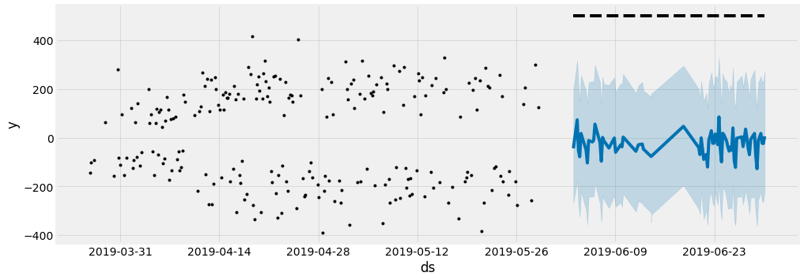

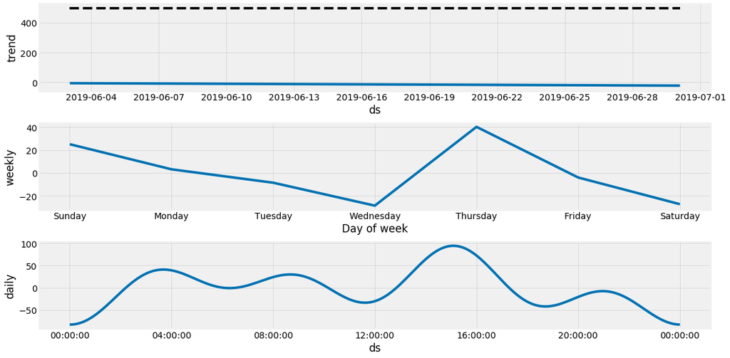

```python
df1=dataframe_test_N2Odry.reset_index().rename(columns={'DateTime': 'ds'})
df1['cap']   = 500
df1['floor'] = -500

forecast_mT_v1 = mT_v1.predict(df1)

fig21      = mT_v1.plot(forecast_mT_v1)
fig22      = mT_v1.plot_components(forecast_mT_v1)

fig21.set_figheight(5)
fig21.set_figwidth(15)

fig22.set_figheight(8)
fig22.set_figwidth(18)
```

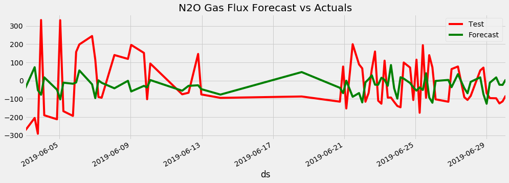

```python
df1=dataframe_test_N2Odry.reset_index().rename(columns={'DateTime': 'ds'})

f, ax = plt.subplots(figsize=(14,5))
f.set_figheight(5)
f.set_figwidth(15)

df1.plot(kind='line', x='ds', y='Flux', color='red', label='Test', ax=ax)
forecast_mT_v1.plot(kind='line',x='ds',y='yhat', color='green',label='Forecast', ax=ax)

plt.title('N2O Gas Flux Forecast vs Actuals')
plt.show()
```

```python
dataframe_train_N2Odry
```

### Check the performance of the tuned model mT_v1

```python
mape = mean_absolute_percentage_error(dataframe_test_N2Odry['Flux'],forecast_mT_v1['yhat'])
print("MAPE",round(mape,4))
```

```
MAPE 104.0288
```

```python
mse = sklearn.metrics.mean_squared_error(dataframe_test_CH4dry,forecast_mT_v1)

rmse = math.sqrt(mse)

print(rmse)
```

[output not shown]

### Cross Validation of the tuned model mT_v1

```python
#horizon = how many days are we going to make forecast
#period  = space between 2 or more training periods (normally 0.5 * horizon)
#initial = size of training period (normally 3* horizon)

df_cv1 = cross_validation(mT_v1, initial='42 days', period='7 days', horizon = '14 days')
df_p1  = performance_metrics(df_cv1)
df_p1
```

[output not shown]

```python
fig3 = plot_cross_validation_metric(df_cv1, metric='mape')
```

[output not shown]

### Using a second approach - try a different combination of parameters

```python
#specify a cap and floor for limiting the forecast within these values

df = dataframe_train_N2Odry.reset_index().rename(columns={'DateTime': 'ds', 'Flux': 'y'})
df['cap']   = 500
df['floor'] = -500


def create_param_combinations(**param_dict):
    param_iter = itertools.product(*param_dict.values())  #take different combinations of the values e.g. 0.005, 0.8, 0.1, multiplicative, linear, 1
    params     = []
    for param in param_iter:
        params.append(param)
    params_df = pd.DataFrame(params, columns=list(param_dict.keys()))
    return params_df

def single_cv_run(history_df, metrics, param_dict):
    m7 = Prophet(**param_dict)
    #m.add_country_holidays(country_name='US')
    m7.fit(history_df)
    df_cv = cross_validation(m7, initial='42 days', period='7 days', horizon = '14 days')
    df_p = performance_metrics(df_cv).mean().to_frame().T
    df_p['params'] = str(param_dict)
    df_p = df_p.loc[:, metrics]
    return df_p

param_grid = {
                'changepoint_prior_scale': [0.05, 0.1, 0.2, 0.3, 0.4, 0.5],
                'changepoint_range': [0.8, 0.9],
                'seasonality_prior_scale':[0.1, 1, 10.0],
                #'holidays_prior_scale':[0.1, 1, 10.0],
                'seasonality_mode': ['multiplicative', 'additive'],
                'growth': ['linear', 'logistic'],
                #'yearly_seasonality': [5, 10, 20]
                'weekly_seasonality' : [1, 3, 5]
             }

metrics = ['horizon', 'rmse', 'mape', 'params']

results = []

params_df = create_param_combinations(**param_grid)
for param in params_df.values:
    param_dict = dict(zip(params_df.keys(), param))
    cv_df = single_cv_run(df, metrics, param_dict)
    results.append(cv_df)

results_df2 = pd.concat(results).reset_index(drop=True)
best_param = results_df2.loc[results_df2['mape'] == min(results_df2['mape']), ['params']]
print(f'\n The best param combination is {best_param.values[0][0]}')
results_df2
```

[output not shown]

[output cut: 809 more lines]

[output not shown]

```
 The best param combination is {'changepoint_prior_scale': 0.5, 'changepoint_range': 0.9, 'seasonality_prior_scale': 0.1, 'seasonality_mode': 'multiplicative', 'growth': 'linear', 'weekly_seasonality': 1}
```

|  | horizon | rmse | mape | params |
| --- | --- | --- | --- | --- |
| 0 | 7 days 03:12:06.233766 | 218.545 | 1.01013 | {'changepoint_prior_scale': 0.05, 'changepoint_range': 0.8, 'seasonality_prior_scale': 0.1, 'seasonality_mode': 'multiplicative', 'growth': 'linear', 'weekly_seasonality': 1} |
| 1 | 7 days 03:12:06.233766 | 218.696 | 1.01086 | {'changepoint_prior_scale': 0.05, 'changepoint_range': 0.8, 'seasonality_prior_scale': 0.1, 'seasonality_mode': 'multiplicative', 'growth': 'linear', 'weekly_seasonality': 3} |
| 2 | 7 days 03:12:06.233766 | 219.929 | 1.01422 | {'changepoint_prior_scale': 0.05, 'changepoint_range': 0.8, 'seasonality_prior_scale': 0.1, 'seasonality_mode': 'multiplicative', 'growth': 'linear', 'weekly_seasonality': 5} |
| 3 | 7 days 03:12:06.233766 | 219.582 | 1.01205 | {'changepoint_prior_scale': 0.05, 'changepoint_range': 0.8, 'seasonality_prior_scale': 0.1, 'seasonality_mode': 'multiplicative', 'growth': 'logistic', 'weekly_seasonality': 1} |
| 4 | 7 days 03:12:06.233766 | 220.193 | 1.0149 | {'changepoint_prior_scale': 0.05, 'changepoint_range': 0.8, 'seasonality_prior_scale': 0.1, 'seasonality_mode': 'multiplicative', 'growth': 'logistic', 'weekly_seasonality': 3} |
| 5 | 7 days 03:12:06.233766 | 221.319 | 1.01787 | {'changepoint_prior_scale': 0.05, 'changepoint_range': 0.8, 'seasonality_prior_scale': 0.1, 'seasonality_mode': 'multiplicative', 'growth': 'logistic', 'weekly_seasonality': 5} |
| 6 | 7 days 03:12:06.233766 | 221.692 | 1.0277 | {'changepoint_prior_scale': 0.05, 'changepoint_range': 0.8, 'seasonality_prior_scale': 0.1, 'seasonality_mode': 'additive', 'growth': 'linear', 'weekly_seasonality': 1} |
| 7 | 7 days 03:12:06.233766 | 221.98 | 1.04687 | {'changepoint_prior_scale': 0.05, 'changepoint_range': 0.8, 'seasonality_prior_scale': 0.1, 'seasonality_mode': 'additive', 'growth': 'linear', 'weekly_seasonality': 3} |
| 8 | 7 days 03:12:06.233766 | 221.34 | 1.04708 | {'changepoint_prior_scale': 0.05, 'changepoint_range': 0.8, 'seasonality_prior_scale': 0.1, 'seasonality_mode': 'additive', 'growth': 'linear', 'weekly_seasonality': 5} |
| 9 | 7 days 03:12:06.233766 | 221.843 | 1.02514 | {'changepoint_prior_scale': 0.05, 'changepoint_range': 0.8, 'seasonality_prior_scale': 0.1, 'seasonality_mode': 'additive', 'growth': 'logistic', 'weekly_seasonality': 1} |
| 10 | 7 days 03:12:06.233766 | 224.909 | 1.05517 | {'changepoint_prior_scale': 0.05, 'changepoint_range': 0.8, 'seasonality_prior_scale': 0.1, 'seasonality_mode': 'additive', 'growth': 'logistic', 'weekly_seasonality': 3} |
| 11 | 7 days 03:12:06.233766 | 224.404 | 1.05462 | {'changepoint_prior_scale': 0.05, 'changepoint_range': 0.8, 'seasonality_prior_scale': 0.1, 'seasonality_mode': 'additive', 'growth': 'logistic', 'weekly_seasonality': 5} |
| 12 | 7 days 03:12:06.233766 | 220.144 | 1.01319 | {'changepoint_prior_scale': 0.05, 'changepoint_range': 0.8, 'seasonality_prior_scale': 1.0, 'seasonality_mode': 'multiplicative', 'growth': 'linear', 'weekly_seasonality': 1} |
| 13 | 7 days 03:12:06.233766 | 219.325 | 1.01482 | {'changepoint_prior_scale': 0.05, 'changepoint_range': 0.8, 'seasonality_prior_scale': 1.0, 'seasonality_mode': 'multiplicative', 'growth': 'linear', 'weekly_seasonality': 3} |
| 14 | 7 days 03:12:06.233766 | 220.41 | 1.01684 | {'changepoint_prior_scale': 0.05, 'changepoint_range': 0.8, 'seasonality_prior_scale': 1.0, 'seasonality_mode': 'multiplicative', 'growth': 'linear', 'weekly_seasonality': 5} |
| 15 | 7 days 03:12:06.233766 | 218.969 | 1.01088 | {'changepoint_prior_scale': 0.05, 'changepoint_range': 0.8, 'seasonality_prior_scale': 1.0, 'seasonality_mode': 'multiplicative', 'growth': 'logistic', 'weekly_seasonality': 1} |
| 16 | 7 days 03:12:06.233766 | 219.323 | 1.01318 | {'changepoint_prior_scale': 0.05, 'changepoint_range': 0.8, 'seasonality_prior_scale': 1.0, 'seasonality_mode': 'multiplicative', 'growth': 'logistic', 'weekly_seasonality': 3} |
| 17 | 7 days 03:12:06.233766 | 220.956 | 1.0176 | {'changepoint_prior_scale': 0.05, 'changepoint_range': 0.8, 'seasonality_prior_scale': 1.0, 'seasonality_mode': 'multiplicative', 'growth': 'logistic', 'weekly_seasonality': 5} |
| 18 | 7 days 03:12:06.233766 | 220.752 | 1.02284 | {'changepoint_prior_scale': 0.05, 'changepoint_range': 0.8, 'seasonality_prior_scale': 1.0, 'seasonality_mode': 'additive', 'growth': 'linear', 'weekly_seasonality': 1} |
| 19 | 7 days 03:12:06.233766 | 225.974 | 1.06028 | {'changepoint_prior_scale': 0.05, 'changepoint_range': 0.8, 'seasonality_prior_scale': 1.0, 'seasonality_mode': 'additive', 'growth': 'linear', 'weekly_seasonality': 3} |
| 20 | 7 days 03:12:06.233766 | 223.886 | 1.05726 | {'changepoint_prior_scale': 0.05, 'changepoint_range': 0.8, 'seasonality_prior_scale': 1.0, 'seasonality_mode': 'additive', 'growth': 'linear', 'weekly_seasonality': 5} |
| 21 | 7 days 03:12:06.233766 | 222.04 | 1.02546 | {'changepoint_prior_scale': 0.05, 'changepoint_range': 0.8, 'seasonality_prior_scale': 1.0, 'seasonality_mode': 'additive', 'growth': 'logistic', 'weekly_seasonality': 1} |
| 22 | 7 days 03:12:06.233766 | 227.274 | 1.06107 | {'changepoint_prior_scale': 0.05, 'changepoint_range': 0.8, 'seasonality_prior_scale': 1.0, 'seasonality_mode': 'additive', 'growth': 'logistic', 'weekly_seasonality': 3} |
| 23 | 7 days 03:12:06.233766 | 225.717 | 1.05859 | {'changepoint_prior_scale': 0.05, 'changepoint_range': 0.8, 'seasonality_prior_scale': 1.0, 'seasonality_mode': 'additive', 'growth': 'logistic', 'weekly_seasonality': 5} |
| 24 | 7 days 03:12:06.233766 | 218.485 | 1.01026 | {'changepoint_prior_scale': 0.05, 'changepoint_range': 0.8, 'seasonality_prior_scale': 10.0, 'seasonality_mode': 'multiplicative', 'growth': 'linear', 'weekly_seasonality': 1} |
| 25 | 7 days 03:12:06.233766 | 219.847 | 1.0161 | {'changepoint_prior_scale': 0.05, 'changepoint_range': 0.8, 'seasonality_prior_scale': 10.0, 'seasonality_mode': 'multiplicative', 'growth': 'linear', 'weekly_seasonality': 3} |
| 26 | 7 days 03:12:06.233766 | 219.87 | 1.01568 | {'changepoint_prior_scale': 0.05, 'changepoint_range': 0.8, 'seasonality_prior_scale': 10.0, 'seasonality_mode': 'multiplicative', 'growth': 'linear', 'weekly_seasonality': 5} |
| 27 | 7 days 03:12:06.233766 | 219.097 | 1.01117 | {'changepoint_prior_scale': 0.05, 'changepoint_range': 0.8, 'seasonality_prior_scale': 10.0, 'seasonality_mode': 'multiplicative', 'growth': 'logistic', 'weekly_seasonality': 1} |
| 28 | 7 days 03:12:06.233766 | 222.952 | 1.02175 | {'changepoint_prior_scale': 0.05, 'changepoint_range': 0.8, 'seasonality_prior_scale': 10.0, 'seasonality_mode': 'multiplicative', 'growth': 'logistic', 'weekly_seasonality': 3} |
| 29 | 7 days 03:12:06.233766 | 222.759 | 1.02167 | {'changepoint_prior_scale': 0.05, 'changepoint_range': 0.8, 'seasonality_prior_scale': 10.0, 'seasonality_mode': 'multiplicative', 'growth': 'logistic', 'weekly_seasonality': 5} |

[output cut: 402 more lines]

```python
results_df2.to_csv('HyperParameter_Tuning_Results_N2O_mTv2.csv')

best_param = results_df2.loc[results_df2['mape'] == min(results_df2['mape']), ['params']]
print(f'\n The best param combination is {best_param.values[0][0]}')
```

```
 The best param combination is {'changepoint_prior_scale': 0.5, 'changepoint_range': 0.9, 'seasonality_prior_scale': 0.1, 'seasonality_mode': 'multiplicative', 'growth': 'linear', 'weekly_seasonality': 1}
```

### Create model mT_v2 with the actual parameter combination

```python
mT_v2 = Prophet(
    changepoint_prior_scale=0.5,
    changepoint_range=0.9,
    seasonality_prior_scale=0.1,
    seasonality_mode='multiplicative',
    growth='linear',
    weekly_seasonality= 1
)

mT_v2.fit(df)
```

```
INFO:fbprophet:Disabling yearly seasonality. Run prophet with yearly_seasonality=True to override this.
```

```
<fbprophet.forecaster.Prophet at 0x7f82824e4850>
```

### Run the final model mT_v2 with the actual parameter combination

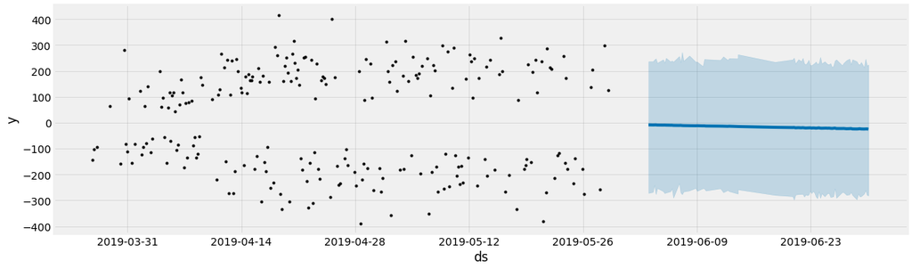

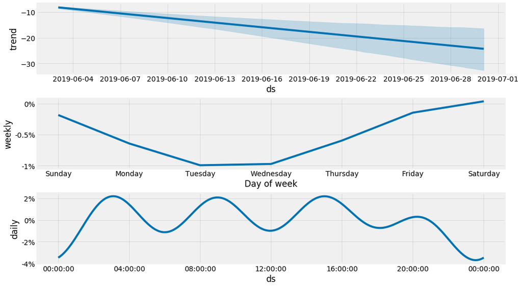

```python
forecast_mT_v2 = mT_v2.predict(df=dataframe_test_N2Odry.reset_index().rename(columns={'DateTime': 'ds'}))

#mT.add_country_holidays(country_name='US')

#future['cap'] = 60000
#future['floor'] = 0
#forecastT2 = mT2.predict(futureT2)
fig21      = mT_v2.plot(forecast_mT_v2)
fig22      = mT_v2.plot_components(forecast_mT_v2)

fig21.set_figheight(5)
fig21.set_figwidth(18)

fig22.set_figheight(8)
fig22.set_figwidth(16)
```

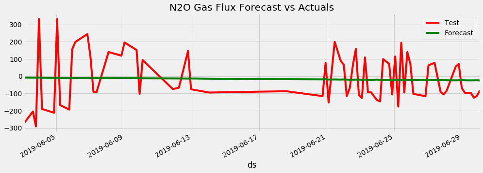

```python
df1=dataframe_test_N2Odry.reset_index().rename(columns={'DateTime': 'ds'})

f, ax = plt.subplots(figsize=(14,5))
f.set_figheight(5)
f.set_figwidth(15)

df1.plot(kind='line', x='ds', y='Flux', color='red', label='Test', ax=ax)
forecast_mT_v2.plot(kind='line',x='ds',y='yhat', color='green',label='Forecast', ax=ax)

plt.title('N2O Gas Flux Forecast vs Actuals')
plt.show()
```

### Check the performance of the tuned model mT_v2

```python
mape = mean_absolute_percentage_error(dataframe_test_N2Odry['Flux'],forecast_mT_v2['yhat'])
print("MAPE",round(mape,4))
```

```
MAPE 96.9889
```

```python
mse = sklearn.metrics.mean_squared_error(dataframe_test_CH4dry,forecast_mT_v2)

rmse = math.sqrt(mse)

print(rmse)
```

[output not shown]

### Cross Validation of the tuned model mT_v2

```python
#horizon = how many days are we going to make forecast
#period  = space between 2 or more training periods (normally 0.5 * horizon)
#initial = size of training period (normally 3* horizon)

df_cv22 = cross_validation(mT_v2, initial='42 days', period='7 days', horizon = '14 days')
df_p22 = performance_metrics(df_cv22)
df_p22
```

```
INFO:fbprophet:Making 2 forecasts with cutoffs between 2019-05-08 03:33:00 and 2019-05-15 03:33:00
```

|  | horizon | mse | rmse | mae | mape | coverage |
| --- | --- | --- | --- | --- | --- | --- |
| 0 | 1 days 06:14:00 | 56368.840701 | 237.421231 | 230.001737 | 1.016810 | 0.500 |
| 1 | 1 days 06:20:00 | 59612.340753 | 244.156386 | 237.229558 | 0.997087 | 0.375 |
| 2 | 1 days 10:38:00 | 64961.974541 | 254.876391 | 249.349663 | 1.017780 | 0.250 |
| 3 | 1 days 19:09:00 | 61164.003969 | 247.313574 | 241.594727 | 1.034762 | 0.375 |
| 4 | 1 days 19:15:00 | 50450.931429 | 224.612848 | 216.535629 | 1.020316 | 0.500 |
| 5 | 1 days 23:33:00 | 49830.991521 | 223.228563 | 215.390724 | 0.999868 | 0.500 |
| 6 | 2 days 03:51:00 | 48218.893440 | 219.588008 | 210.545914 | 1.030455 | 0.500 |
| 7 | 2 days 08:10:00 | 52050.088624 | 228.144885 | 220.949181 | 1.022224 | 0.500 |
| 8 | 2 days 12:28:00 | 46900.847860 | 216.566036 | 209.995335 | 1.032565 | 0.625 |
| 9 | 2 days 16:41:00 | 53861.579579 | 232.080976 | 221.606870 | 1.047520 | 0.625 |
| 10 | 2 days 16:46:00 | 53176.799613 | 230.600953 | 220.309864 | 1.047968 | 0.625 |
| 11 | 2 days 20:59:00 | 48147.680074 | 219.425796 | 202.849004 | 1.022018 | 0.625 |
| 12 | 2 days 21:04:00 | 50935.035242 | 225.687916 | 212.106308 | 1.057622 | 0.625 |
| 13 | 3 days 01:23:00 | 50065.137771 | 223.752403 | 210.429904 | 1.079510 | 0.625 |
| 14 | 3 days 09:59:00 | 50087.372790 | 223.802084 | 210.505381 | 1.040527 | 0.625 |
| 15 | 3 days 14:12:00 | 48279.115099 | 219.725090 | 206.166805 | 1.036024 | 0.625 |
| 16 | 3 days 18:31:00 | 47617.331888 | 218.213959 | 204.368826 | 1.028676 | 0.625 |
| 17 | 3 days 18:36:00 | 35678.462810 | 188.887434 | 180.593719 | 1.043997 | 0.750 |
| 18 | 3 days 22:49:00 | 30297.022803 | 174.060400 | 167.578468 | 1.043679 | 0.875 |
| 19 | 3 days 22:54:00 | 36917.084013 | 192.138190 | 188.530973 | 1.051104 | 0.750 |
| 20 | 4 days 03:08:00 | 38224.045322 | 195.509706 | 191.788470 | 1.028134 | 0.750 |
| 21 | 4 days 03:13:00 | 35939.723632 | 189.577751 | 186.889703 | 1.004224 | 0.875 |
| 22 | 4 days 07:31:00 | 33899.497788 | 184.118163 | 177.679307 | 0.992147 | 0.875 |
| 23 | 4 days 11:44:00 | 32791.991202 | 181.085591 | 174.579468 | 0.993845 | 0.875 |
| 24 | 4 days 11:49:00 | 35217.914969 | 187.664368 | 180.614589 | 0.972821 | 0.875 |
| 25 | 4 days 16:02:00 | 36409.585678 | 190.812960 | 184.119533 | 0.944575 | 0.875 |
| 26 | 4 days 20:27:00 | 42073.540209 | 205.118357 | 197.676078 | 0.943843 | 0.750 |
| 27 | 5 days 00:39:00 | 41449.546279 | 203.591616 | 196.356915 | 0.947999 | 0.875 |
| 28 | 5 days 00:45:00 | 38607.667033 | 196.488338 | 188.570650 | 0.938787 | 0.875 |
| 29 | 5 days 04:57:00 | 34249.493808 | 185.066188 | 174.831083 | 0.936952 | 0.875 |
| 30 | 5 days 17:52:00 | 39867.028300 | 199.667294 | 193.655160 | 0.959396 | 0.875 |
| 31 | 5 days 17:58:00 | 39703.059521 | 199.256266 | 193.155996 | 0.968391 | 0.875 |
| 32 | 5 days 22:11:00 | 52786.231030 | 229.752543 | 214.282954 | 0.983913 | 0.750 |
| 33 | 5 days 22:16:00 | 53227.827634 | 230.711568 | 215.453064 | 0.979094 | 0.750 |
| 34 | 6 days 02:35:00 | 51023.170698 | 225.883091 | 210.956341 | 0.981716 | 0.875 |
| 35 | 6 days 06:48:00 | 54150.521329 | 232.702646 | 217.071710 | 0.993831 | 0.750 |
| 36 | 6 days 11:06:00 | 60709.180893 | 246.392331 | 232.471454 | 1.004616 | 0.625 |
| 37 | 6 days 11:11:00 | 65474.361870 | 255.879585 | 247.147517 | 1.006392 | 0.625 |
| 38 | 6 days 19:43:00 | 64245.043311 | 253.466059 | 244.261289 | 1.006193 | 0.625 |
| 39 | 7 days 00:01:00 | 65685.660506 | 256.292139 | 248.298954 | 0.979152 | 0.625 |
| 40 | 7 days 00:06:00 | 51483.979438 | 226.900814 | 224.567241 | 0.990998 | 0.750 |
| 41 | 7 days 08:38:00 | 53146.013599 | 230.534192 | 228.538387 | 1.010536 | 0.750 |
| 42 | 7 days 13:01:00 | 50021.211618 | 223.654223 | 220.531196 | 0.981696 | 0.750 |
| 43 | 7 days 17:15:00 | 42533.085153 | 206.235509 | 202.551536 | 0.987720 | 0.875 |
| 44 | 7 days 17:20:00 | 44707.549361 | 211.441598 | 206.306246 | 0.984367 | 0.875 |
| 45 | 7 days 21:34:00 | 40652.208435 | 201.623928 | 194.692711 | 1.008316 | 0.875 |
| 46 | 7 days 21:38:00 | 39487.974367 | 198.715813 | 191.614433 | 1.000913 | 0.875 |
| 47 | 8 days 06:14:00 | 45151.279976 | 212.488306 | 203.341775 | 1.019230 | 0.750 |
| 48 | 8 days 10:29:00 | 47549.019023 | 218.057376 | 208.657144 | 0.997707 | 0.750 |
| 49 | 8 days 14:48:00 | 44719.113257 | 211.468942 | 201.449714 | 1.000045 | 0.750 |
| 50 | 8 days 19:06:00 | 44626.006996 | 211.248685 | 201.162253 | 1.007498 | 0.750 |
| 51 | 8 days 19:09:00 | 48545.420470 | 220.330253 | 212.055885 | 1.009702 | 0.750 |
| 52 | 8 days 23:25:00 | 41496.940546 | 203.707979 | 197.825960 | 1.026693 | 0.875 |
| 53 | 9 days 16:38:00 | 47037.967397 | 216.882381 | 212.617287 | 1.020571 | 0.875 |
| 54 | 9 days 16:41:00 | 59030.869209 | 242.962691 | 235.099452 | 1.043393 | 0.750 |
| 55 | 9 days 20:56:00 | 51407.874998 | 226.733048 | 217.666196 | 1.042100 | 0.875 |
| 56 | 9 days 20:59:00 | 44310.603689 | 210.500840 | 194.854622 | 1.015544 | 0.875 |
| 57 | 10 days 14:12:00 | 45880.313171 | 214.196903 | 199.108477 | 1.022790 | 0.875 |
| 58 | 10 days 18:29:00 | 47151.529497 | 217.144029 | 202.734315 | 1.038109 | 0.875 |
| 59 | 10 days 18:31:00 | 45298.173725 | 212.833676 | 198.223290 | 1.041730 | 0.875 |
| 60 | 10 days 22:47:00 | 50975.188824 | 225.776856 | 210.131020 | 1.038546 | 0.750 |
| 61 | 10 days 22:49:00 | 46793.732155 | 216.318589 | 199.974192 | 1.053430 | 0.750 |
| 62 | 11 days 03:08:00 | 36039.386487 | 189.840424 | 180.754131 | 1.031637 | 0.875 |
| 63 | 11 days 11:44:00 | 37198.438921 | 192.868968 | 184.307057 | 1.041707 | 0.875 |
| 64 | 11 days 16:02:00 | 40423.000927 | 201.054721 | 197.893967 | 1.059013 | 0.875 |
| 65 | 11 days 20:19:00 | 37373.255679 | 193.321638 | 188.619915 | 1.033639 | 0.875 |
| 66 | 12 days 00:37:00 | 37613.716542 | 193.942560 | 189.245126 | 1.019720 | 0.875 |
| 67 | 12 days 00:39:00 | 39284.646931 | 198.203549 | 193.344957 | 0.990091 | 0.875 |
| 68 | 12 days 04:57:00 | 30130.393881 | 173.581087 | 169.162926 | 0.959500 | 1.000 |
| 69 | 12 days 17:52:00 | 32400.508281 | 180.001412 | 175.161769 | 0.926316 | 1.000 |
| 70 | 12 days 22:09:00 | 36225.217938 | 190.329236 | 183.286109 | 0.944168 | 0.875 |
| 71 | 12 days 22:11:00 | 52812.950993 | 229.810685 | 211.764222 | 0.932002 | 0.750 |
| 72 | 13 days 06:48:00 | 59697.632658 | 244.330990 | 226.583449 | 0.957915 | 0.625 |
| 73 | 13 days 11:04:00 | 68093.485532 | 260.947285 | 246.761824 | 0.962601 | 0.500 |
| 74 | 13 days 11:06:00 | 71971.037641 | 268.274184 | 255.238743 | 0.958538 | 0.375 |
| 75 | 13 days 19:43:00 | 70431.635315 | 265.389592 | 251.487285 | 0.957545 | 0.375 |
| 76 | 14 days 00:00:00 | 71024.032190 | 266.503344 | 254.336776 | 0.972889 | 0.375 |

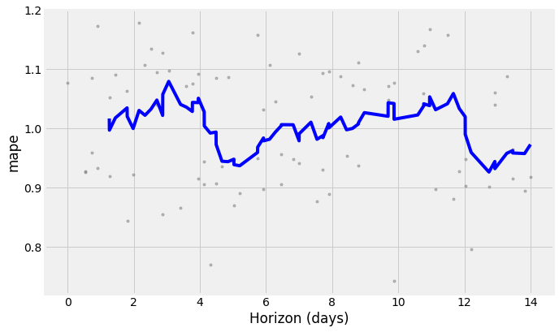

```python
fig3 = plot_cross_validation_metric(df_cv22, metric='mape')
```

### Test accuracy of final model mT_v2 with test data set

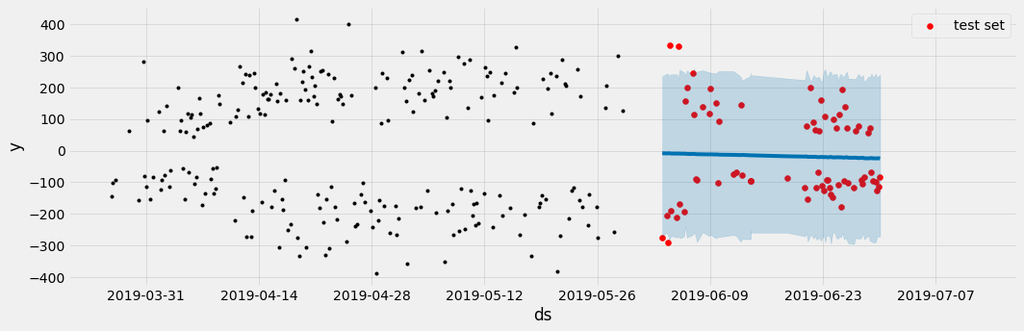

```python
# Plot the forecast with the actuals
f, ax = plt.subplots(1)
f.set_figheight(5)
f.set_figwidth(15)
ax.scatter(dataframe_test_N2Odry.index, dataframe_test_N2Odry['Flux'], color='r', label="test set")
ax.legend()
fig = mT_v2.plot(forecast_mT_v2, ax=ax)
```

### Set up final model (model resulting from hyperparameter tuning) to generate forecasts on the gas flux

#### Forecast for next 48 hours

```python
future_48hT2     = mT_v2.make_future_dataframe(periods=48, freq='H', include_history = False)
forecast_hoursT2 = mT_v2.predict(future_48hT2)

# Plot the forecast
f, ax = plt.subplots(1)
f.set_figheight(5)
f.set_figwidth(15)
fig = mT_v2.plot(forecast_hoursT2,ax=ax)
plt.show()

# Plot the components of the model
fig1 = mT_v2.plot_components(forecast_hoursT2)
fig1.set_figwidth(20)
```

[output not shown]

#### Forecast for next 2 weeks

```python
future_2W2        = mT_v2.make_future_dataframe(periods=14, freq='D', include_history = False)
forecast_2Wks2    = mT_v2.predict(future_2W2)

# Plot the forecast
f, ax = plt.subplots(1)
f.set_figheight(5)
f.set_figwidth(15)
fig = mT_v2.plot(forecast_2Wks2,ax=ax)
plt.show()

# Plot the components of the model
fig1 = mT_v2.plot_components(forecast_2Wks2)
fig1.set_figwidth(20)
```

[output not shown]

#### Forecast for next 2 months

```python
### future_2M2        = mT_v1.make_future_dataframe(periods=30*2, freq='D', include_history = False)
forecast_hours2M2 = mT_v2.predict(future_2M2)

# Plot the forecast
f, ax = plt.subplots(1)
f.set_figheight(5)
f.set_figwidth(15)
fig = mT_v2.plot(forecast_hours2M2,ax=ax)
plt.show()

# Plot the components of the model
fig1 = mT_v2.plot_components(forecast_hours2M2)
fig1.set_figwidth(20)
```

[output not shown]

```python
df = df_N2Odry.reset_index().rename(columns={'DateTime': 'ds', 'Flux': 'y'})

# Plot the forecast with the actuals
f1, ax = plt.subplots(1)
f1.set_figheight(5)
f1.set_figwidth(15)
ax.scatter(df.ds, df['y'], color='r', label="test set")
ax.legend()

fig2 = mT_v2.plot(forecast_2Wks2, ax=ax)
```

[output not shown]

### Using a third approach - try a different combination of parameters

```python
#specify a cap and floor for limiting the forecast within these values

df = dataframe_train_N2Odry.reset_index().rename(columns={'DateTime': 'ds', 'Flux': 'y'})
df['cap']   = 500
df['floor'] = -500


def create_param_combinations(**param_dict):
    param_iter = itertools.product(*param_dict.values())  #take different combinations of the values e.g. 0.005, 0.8, 0.1, multiplicative, linear, 1
    params     = []
    for param in param_iter:
        params.append(param)
    params_df = pd.DataFrame(params, columns=list(param_dict.keys()))
    return params_df

def single_cv_run(history_df, metrics, param_dict):
    m7 = Prophet(**param_dict)
    #m.add_country_holidays(country_name='US')
    m7.fit(history_df)
    df_cv = cross_validation(m7, initial='42 days', period='7 days', horizon = '14 days')
    df_p = performance_metrics(df_cv).mean().to_frame().T
    df_p['params'] = str(param_dict)
    df_p = df_p.loc[:, metrics]
    return df_p

param_grid = {
                'changepoint_prior_scale': [0.05, 0.1, 0.2, 0.3, 0.4, 0.5],
                'changepoint_range': [0.8, 0.9],
                'seasonality_prior_scale':[0.1, 1, 10.0],
                #'holidays_prior_scale':[0.1, 1, 10.0],
                'seasonality_mode': ['multiplicative', 'additive'],
                'growth': ['linear', 'logistic'],
                #'yearly_seasonality': [5, 10, 20]
                'daily_seasonality' : [1, 3, 5]
             }

metrics = ['horizon', 'rmse', 'mape', 'params']

results = []

params_df = create_param_combinations(**param_grid)
for param in params_df.values:
    param_dict = dict(zip(params_df.keys(), param))
    cv_df = single_cv_run(df, metrics, param_dict)
    results.append(cv_df)

results_df3 = pd.concat(results).reset_index(drop=True)
best_param = results_df3.loc[results_df3['mape'] == min(results_df3['mape']), ['params']]
print(f'\n The best param combination is {best_param.values[0][0]}')
results_df3
```

[output not shown]

[output cut: 809 more lines]

[output not shown]

```
 The best param combination is {'changepoint_prior_scale': 0.5, 'changepoint_range': 0.9, 'seasonality_prior_scale': 0.1, 'seasonality_mode': 'multiplicative', 'growth': 'linear', 'daily_seasonality': 3}
```

|  | horizon | rmse | mape | params |
| --- | --- | --- | --- | --- |
| 0 | 7 days 03:12:06.233766 | 219.363 | 1.01218 | {'changepoint_prior_scale': 0.05, 'changepoint_range': 0.8, 'seasonality_prior_scale': 0.1, 'seasonality_mode': 'multiplicative', 'growth': 'linear', 'daily_seasonality': 1} |
| 1 | 7 days 03:12:06.233766 | 219.393 | 1.01284 | {'changepoint_prior_scale': 0.05, 'changepoint_range': 0.8, 'seasonality_prior_scale': 0.1, 'seasonality_mode': 'multiplicative', 'growth': 'linear', 'daily_seasonality': 3} |
| 2 | 7 days 03:12:06.233766 | 219.199 | 1.01275 | {'changepoint_prior_scale': 0.05, 'changepoint_range': 0.8, 'seasonality_prior_scale': 0.1, 'seasonality_mode': 'multiplicative', 'growth': 'linear', 'daily_seasonality': 5} |
| 3 | 7 days 03:12:06.233766 | 222.188 | 1.01838 | {'changepoint_prior_scale': 0.05, 'changepoint_range': 0.8, 'seasonality_prior_scale': 0.1, 'seasonality_mode': 'multiplicative', 'growth': 'logistic', 'daily_seasonality': 1} |
| 4 | 7 days 03:12:06.233766 | 222.207 | 1.01916 | {'changepoint_prior_scale': 0.05, 'changepoint_range': 0.8, 'seasonality_prior_scale': 0.1, 'seasonality_mode': 'multiplicative', 'growth': 'logistic', 'daily_seasonality': 3} |
| 5 | 7 days 03:12:06.233766 | 219.174 | 1.01275 | {'changepoint_prior_scale': 0.05, 'changepoint_range': 0.8, 'seasonality_prior_scale': 0.1, 'seasonality_mode': 'multiplicative', 'growth': 'logistic', 'daily_seasonality': 5} |
| 6 | 7 days 03:12:06.233766 | 223.543 | 1.03765 | {'changepoint_prior_scale': 0.05, 'changepoint_range': 0.8, 'seasonality_prior_scale': 0.1, 'seasonality_mode': 'additive', 'growth': 'linear', 'daily_seasonality': 1} |
| 7 | 7 days 03:12:06.233766 | 221.958 | 1.04218 | {'changepoint_prior_scale': 0.05, 'changepoint_range': 0.8, 'seasonality_prior_scale': 0.1, 'seasonality_mode': 'additive', 'growth': 'linear', 'daily_seasonality': 3} |
| 8 | 7 days 03:12:06.233766 | 223.064 | 1.05433 | {'changepoint_prior_scale': 0.05, 'changepoint_range': 0.8, 'seasonality_prior_scale': 0.1, 'seasonality_mode': 'additive', 'growth': 'linear', 'daily_seasonality': 5} |
| 9 | 7 days 03:12:06.233766 | 226.454 | 1.04561 | {'changepoint_prior_scale': 0.05, 'changepoint_range': 0.8, 'seasonality_prior_scale': 0.1, 'seasonality_mode': 'additive', 'growth': 'logistic', 'daily_seasonality': 1} |
| 10 | 7 days 03:12:06.233766 | 226.401 | 1.05612 | {'changepoint_prior_scale': 0.05, 'changepoint_range': 0.8, 'seasonality_prior_scale': 0.1, 'seasonality_mode': 'additive', 'growth': 'logistic', 'daily_seasonality': 3} |
| 11 | 7 days 03:12:06.233766 | 227.997 | 1.06829 | {'changepoint_prior_scale': 0.05, 'changepoint_range': 0.8, 'seasonality_prior_scale': 0.1, 'seasonality_mode': 'additive', 'growth': 'logistic', 'daily_seasonality': 5} |
| 12 | 7 days 03:12:06.233766 | 217.83 | 1.00938 | {'changepoint_prior_scale': 0.05, 'changepoint_range': 0.8, 'seasonality_prior_scale': 1.0, 'seasonality_mode': 'multiplicative', 'growth': 'linear', 'daily_seasonality': 1} |
| 13 | 7 days 03:12:06.233766 | 218.285 | 1.01167 | {'changepoint_prior_scale': 0.05, 'changepoint_range': 0.8, 'seasonality_prior_scale': 1.0, 'seasonality_mode': 'multiplicative', 'growth': 'linear', 'daily_seasonality': 3} |
| 14 | 7 days 03:12:06.233766 | 219.716 | 1.01506 | {'changepoint_prior_scale': 0.05, 'changepoint_range': 0.8, 'seasonality_prior_scale': 1.0, 'seasonality_mode': 'multiplicative', 'growth': 'linear', 'daily_seasonality': 5} |
| 15 | 7 days 03:12:06.233766 | 220.61 | 1.01521 | {'changepoint_prior_scale': 0.05, 'changepoint_range': 0.8, 'seasonality_prior_scale': 1.0, 'seasonality_mode': 'multiplicative', 'growth': 'logistic', 'daily_seasonality': 1} |
| 16 | 7 days 03:12:06.233766 | 223.26 | 1.02216 | {'changepoint_prior_scale': 0.05, 'changepoint_range': 0.8, 'seasonality_prior_scale': 1.0, 'seasonality_mode': 'multiplicative', 'growth': 'logistic', 'daily_seasonality': 3} |
| 17 | 7 days 03:12:06.233766 | 221.717 | 1.01991 | {'changepoint_prior_scale': 0.05, 'changepoint_range': 0.8, 'seasonality_prior_scale': 1.0, 'seasonality_mode': 'multiplicative', 'growth': 'logistic', 'daily_seasonality': 5} |
| 18 | 7 days 03:12:06.233766 | 224.58 | 1.04176 | {'changepoint_prior_scale': 0.05, 'changepoint_range': 0.8, 'seasonality_prior_scale': 1.0, 'seasonality_mode': 'additive', 'growth': 'linear', 'daily_seasonality': 1} |
| 19 | 7 days 03:12:06.233766 | 226.357 | 1.05767 | {'changepoint_prior_scale': 0.05, 'changepoint_range': 0.8, 'seasonality_prior_scale': 1.0, 'seasonality_mode': 'additive', 'growth': 'linear', 'daily_seasonality': 3} |
| 20 | 7 days 03:12:06.233766 | 226.738 | 1.06869 | {'changepoint_prior_scale': 0.05, 'changepoint_range': 0.8, 'seasonality_prior_scale': 1.0, 'seasonality_mode': 'additive', 'growth': 'linear', 'daily_seasonality': 5} |
| 21 | 7 days 03:12:06.233766 | 226.425 | 1.04596 | {'changepoint_prior_scale': 0.05, 'changepoint_range': 0.8, 'seasonality_prior_scale': 1.0, 'seasonality_mode': 'additive', 'growth': 'logistic', 'daily_seasonality': 1} |
| 22 | 7 days 03:12:06.233766 | 227.866 | 1.05992 | {'changepoint_prior_scale': 0.05, 'changepoint_range': 0.8, 'seasonality_prior_scale': 1.0, 'seasonality_mode': 'additive', 'growth': 'logistic', 'daily_seasonality': 3} |
| 23 | 7 days 03:12:06.233766 | 228.191 | 1.06947 | {'changepoint_prior_scale': 0.05, 'changepoint_range': 0.8, 'seasonality_prior_scale': 1.0, 'seasonality_mode': 'additive', 'growth': 'logistic', 'daily_seasonality': 5} |
| 24 | 7 days 03:12:06.233766 | 217.689 | 1.00902 | {'changepoint_prior_scale': 0.05, 'changepoint_range': 0.8, 'seasonality_prior_scale': 10.0, 'seasonality_mode': 'multiplicative', 'growth': 'linear', 'daily_seasonality': 1} |
| 25 | 7 days 03:12:06.233766 | 221.905 | 1.02001 | {'changepoint_prior_scale': 0.05, 'changepoint_range': 0.8, 'seasonality_prior_scale': 10.0, 'seasonality_mode': 'multiplicative', 'growth': 'linear', 'daily_seasonality': 3} |
| 26 | 7 days 03:12:06.233766 | 223.206 | 1.02356 | {'changepoint_prior_scale': 0.05, 'changepoint_range': 0.8, 'seasonality_prior_scale': 10.0, 'seasonality_mode': 'multiplicative', 'growth': 'linear', 'daily_seasonality': 5} |
| 27 | 7 days 03:12:06.233766 | 220.317 | 1.01449 | {'changepoint_prior_scale': 0.05, 'changepoint_range': 0.8, 'seasonality_prior_scale': 10.0, 'seasonality_mode': 'multiplicative', 'growth': 'logistic', 'daily_seasonality': 1} |
| 28 | 7 days 03:12:06.233766 | 222.813 | 1.02112 | {'changepoint_prior_scale': 0.05, 'changepoint_range': 0.8, 'seasonality_prior_scale': 10.0, 'seasonality_mode': 'multiplicative', 'growth': 'logistic', 'daily_seasonality': 3} |
| 29 | 7 days 03:12:06.233766 | 220.373 | 1.01663 | {'changepoint_prior_scale': 0.05, 'changepoint_range': 0.8, 'seasonality_prior_scale': 10.0, 'seasonality_mode': 'multiplicative', 'growth': 'logistic', 'daily_seasonality': 5} |

[output cut: 402 more lines]

```python
results_df3.to_csv('HyperParameter_Tuning_Results_N2O_mTv3.csv')

best_param = results_df3.loc[results_df3['mape'] == min(results_df3['mape']), ['params']]
print(f'\n The best param combination is {best_param.values[0][0]}')
```

```
 The best param combination is {'changepoint_prior_scale': 0.5, 'changepoint_range': 0.9, 'seasonality_prior_scale': 0.1, 'seasonality_mode': 'multiplicative', 'growth': 'linear', 'daily_seasonality': 3}
```

### Create final model mT_v3 with the actual parameter combination

```python
mT_v3 = Prophet(
    changepoint_prior_scale=0.5,
    changepoint_range=0.9,
    seasonality_prior_scale=0.1,
    seasonality_mode='multiplicative',
    growth='linear',
    daily_seasonality= 3
)
mT_v3.fit(df)
```

```
INFO:fbprophet:Disabling yearly seasonality. Run prophet with yearly_seasonality=True to override this.
```

```
<fbprophet.forecaster.Prophet at 0x7f8282d83890>
```

### Run the final model with the actual parameter combination

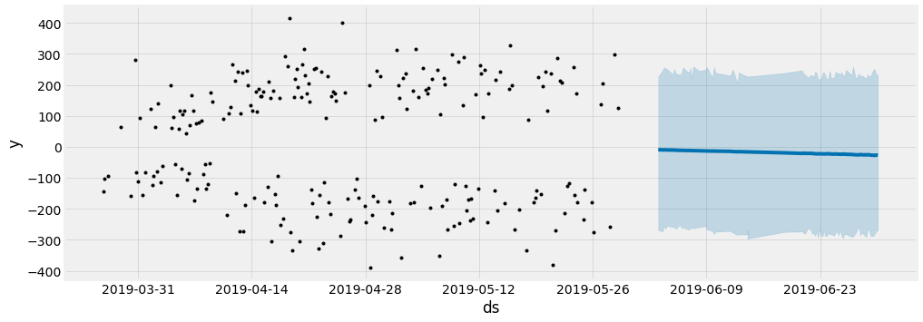

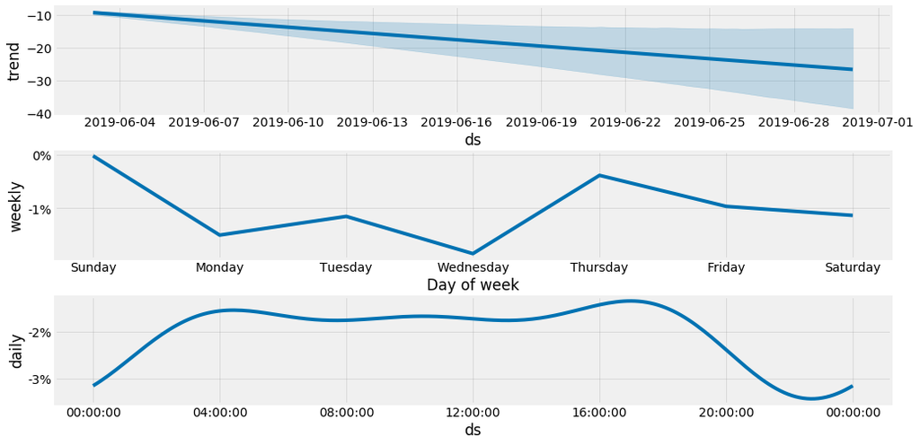

```python
forecast_mT_v3 = mT_v3.predict(df=dataframe_test_N2Odry.reset_index().rename(columns={'DateTime': 'ds'}))

#mT.add_country_holidays(country_name='US')

#future['cap'] = 60000
#future['floor'] = 0
#forecastT2 = mT2.predict(futureT2)
fig21      = mT_v3.plot(forecast_mT_v3)
fig22      = mT_v3.plot_components(forecast_mT_v3)

fig21.set_figheight(5)
fig21.set_figwidth(15)

fig22.set_figheight(7)
fig22.set_figwidth(16)
```

### Check the performance of the tuned model mT_v3

```python
mape = mean_absolute_percentage_error(dataframe_test_N2Odry['Flux'],forecast_mT_v3['yhat'])
print("MAPE",round(mape,4))
```

```
MAPE 96.7024
```

```python
mse = sklearn.metrics.mean_squared_error(dataframe_test_CH4dry,forecast_mT_v3)

rmse = math.sqrt(mse)

print(rmse)
```

[output not shown]

### Cross Validation of the tuned model mT_v3

```python
#horizon = how many days are we going to make forecast
#period  = space between 2 or more training periods (normally 0.5 * horizon)
#initial = size of training period (normally 3* horizon)

df_cv23 = cross_validation(mT_v3, initial='42 days', period='7 days', horizon = '14 days')
df_p23 = performance_metrics(df_cv23)
df_p23
```

```
INFO:fbprophet:Making 2 forecasts with cutoffs between 2019-05-08 03:33:00 and 2019-05-15 03:33:00
```

|  | horizon | mse | rmse | mae | mape | coverage |
| --- | --- | --- | --- | --- | --- | --- |
| 0 | 1 days 06:14:00 | 56323.326561 | 237.325360 | 229.907839 | 1.016734 | 0.500 |
| 1 | 1 days 06:20:00 | 59520.522423 | 243.968282 | 237.040034 | 0.996629 | 0.375 |
| 2 | 1 days 10:38:00 | 64923.941104 | 254.801768 | 249.292615 | 1.017979 | 0.250 |
| 3 | 1 days 19:09:00 | 61206.898687 | 247.400280 | 241.705779 | 1.035680 | 0.375 |
| 4 | 1 days 19:15:00 | 50516.454906 | 224.758659 | 216.649673 | 1.021017 | 0.500 |
| 5 | 1 days 23:33:00 | 49909.450640 | 223.404231 | 215.529834 | 1.000644 | 0.500 |
| 6 | 2 days 03:51:00 | 48336.797862 | 219.856312 | 210.787739 | 1.031694 | 0.500 |
| 7 | 2 days 08:10:00 | 52152.370952 | 228.368936 | 221.117797 | 1.022753 | 0.375 |
| 8 | 2 days 12:28:00 | 46936.238384 | 216.647729 | 210.034133 | 1.032536 | 0.500 |
| 9 | 2 days 16:41:00 | 53945.488688 | 232.261681 | 221.736618 | 1.047813 | 0.500 |
| 10 | 2 days 16:46:00 | 53212.049531 | 230.677371 | 220.347288 | 1.047878 | 0.500 |
| 11 | 2 days 20:59:00 | 48128.625412 | 219.382373 | 202.700387 | 1.020409 | 0.500 |
| 12 | 2 days 21:04:00 | 50951.838252 | 225.725139 | 212.073676 | 1.056783 | 0.500 |
| 13 | 3 days 01:23:00 | 50096.657912 | 223.822827 | 210.428874 | 1.078851 | 0.500 |
| 14 | 3 days 09:59:00 | 50101.286849 | 223.833167 | 210.444628 | 1.039556 | 0.500 |
| 15 | 3 days 14:12:00 | 48343.632240 | 219.871854 | 206.243726 | 1.035848 | 0.625 |
| 16 | 3 days 18:31:00 | 47735.933508 | 218.485545 | 204.595781 | 1.029408 | 0.625 |
| 17 | 3 days 18:36:00 | 35810.694522 | 189.237138 | 180.880593 | 1.045235 | 0.750 |
| 18 | 3 days 22:49:00 | 30485.334680 | 174.600500 | 168.012786 | 1.045817 | 0.875 |
| 19 | 3 days 22:54:00 | 37106.237872 | 192.629795 | 189.029873 | 1.054187 | 0.750 |
| 20 | 4 days 03:08:00 | 38325.115974 | 195.768016 | 192.073041 | 1.030168 | 0.750 |
| 21 | 4 days 03:13:00 | 35963.746759 | 189.641100 | 187.008488 | 1.005546 | 0.875 |
| 22 | 4 days 07:31:00 | 33934.905364 | 184.214292 | 177.797556 | 0.993111 | 0.875 |
| 23 | 4 days 11:44:00 | 32783.573057 | 181.062346 | 174.591807 | 0.994273 | 0.875 |
| 24 | 4 days 11:49:00 | 35174.990467 | 187.549968 | 180.525182 | 0.972596 | 0.875 |
| 25 | 4 days 16:02:00 | 36314.114436 | 190.562626 | 183.876152 | 0.943393 | 0.875 |
| 26 | 4 days 20:27:00 | 41991.929866 | 204.919325 | 197.418911 | 0.942318 | 0.750 |
| 27 | 5 days 00:39:00 | 41344.961981 | 203.334606 | 196.048798 | 0.946258 | 0.875 |
| 28 | 5 days 00:45:00 | 38555.975839 | 196.356757 | 188.376056 | 0.937498 | 0.875 |
| 29 | 5 days 04:57:00 | 34223.656925 | 184.996370 | 174.670092 | 0.935577 | 0.875 |
| 30 | 5 days 17:52:00 | 39818.888446 | 199.546707 | 193.497043 | 0.958518 | 0.875 |
| 31 | 5 days 17:58:00 | 39646.113974 | 199.113319 | 192.972375 | 0.967370 | 0.875 |
| 32 | 5 days 22:11:00 | 52800.562669 | 229.783730 | 214.182598 | 0.983087 | 0.750 |
| 33 | 5 days 22:16:00 | 53250.799808 | 230.761348 | 215.379026 | 0.978425 | 0.750 |
| 34 | 6 days 02:35:00 | 51054.093328 | 225.951529 | 210.912945 | 0.981259 | 0.875 |
| 35 | 6 days 06:48:00 | 54277.089227 | 232.974439 | 217.212351 | 0.994089 | 0.750 |
| 36 | 6 days 11:06:00 | 60810.477445 | 246.597805 | 232.582442 | 1.004854 | 0.625 |
| 37 | 6 days 11:11:00 | 65598.718093 | 256.122467 | 247.338580 | 1.007194 | 0.625 |
| 38 | 6 days 19:43:00 | 64356.244704 | 253.685326 | 244.410889 | 1.006764 | 0.625 |
| 39 | 7 days 00:01:00 | 65759.640207 | 256.436425 | 248.346486 | 0.979141 | 0.625 |
| 40 | 7 days 00:06:00 | 51468.765502 | 226.867286 | 224.489328 | 0.990585 | 0.750 |
| 41 | 7 days 08:38:00 | 53216.373539 | 230.686743 | 228.657866 | 1.011044 | 0.750 |
| 42 | 7 days 13:01:00 | 50008.015573 | 223.624720 | 220.439502 | 0.981126 | 0.750 |
| 43 | 7 days 17:15:00 | 42486.457491 | 206.122433 | 202.450391 | 0.987534 | 0.875 |
| 44 | 7 days 17:20:00 | 44667.827617 | 211.347646 | 206.222997 | 0.984265 | 0.875 |
| 45 | 7 days 21:34:00 | 40640.950853 | 201.596009 | 194.739773 | 1.009453 | 0.875 |
| 46 | 7 days 21:38:00 | 39474.208928 | 198.681174 | 191.637981 | 1.001894 | 0.875 |
| 47 | 8 days 06:14:00 | 45221.601954 | 212.653714 | 203.531793 | 1.020907 | 0.750 |
| 48 | 8 days 10:29:00 | 47564.840305 | 218.093650 | 208.740911 | 0.999015 | 0.750 |
| 49 | 8 days 14:48:00 | 44728.897042 | 211.492073 | 201.564476 | 1.001798 | 0.750 |
| 50 | 8 days 19:06:00 | 44625.274278 | 211.246951 | 201.242734 | 1.009008 | 0.750 |
| 51 | 8 days 19:09:00 | 48550.984787 | 220.342880 | 212.112407 | 1.010795 | 0.750 |
| 52 | 8 days 23:25:00 | 41560.372619 | 203.863613 | 198.005255 | 1.028350 | 0.875 |
| 53 | 9 days 16:38:00 | 47092.641914 | 217.008391 | 212.703347 | 1.021151 | 0.875 |
| 54 | 9 days 16:41:00 | 59116.570060 | 243.138993 | 235.300040 | 1.044601 | 0.750 |
| 55 | 9 days 20:56:00 | 51473.200174 | 226.877060 | 217.894346 | 1.043862 | 0.875 |
| 56 | 9 days 20:59:00 | 44428.851656 | 210.781526 | 195.120265 | 1.016727 | 0.875 |
| 57 | 10 days 14:12:00 | 46012.078863 | 214.504263 | 199.378237 | 1.023858 | 0.875 |
| 58 | 10 days 18:29:00 | 47383.975744 | 217.678607 | 203.289205 | 1.040800 | 0.875 |
| 59 | 10 days 18:31:00 | 45533.916447 | 213.386777 | 198.801105 | 1.044643 | 0.875 |
| 60 | 10 days 22:47:00 | 51262.938943 | 226.413204 | 210.774765 | 1.041554 | 0.750 |
| 61 | 10 days 22:49:00 | 47067.598065 | 216.950681 | 200.607750 | 1.056547 | 0.750 |
| 62 | 11 days 03:08:00 | 36283.319788 | 190.481810 | 181.294025 | 1.034304 | 0.875 |
| 63 | 11 days 11:44:00 | 37405.198188 | 193.404235 | 184.721640 | 1.043464 | 0.875 |
| 64 | 11 days 16:02:00 | 40631.640906 | 201.572917 | 198.373528 | 1.061709 | 0.875 |
| 65 | 11 days 20:19:00 | 37470.465379 | 193.572894 | 188.765966 | 1.034204 | 0.875 |
| 66 | 12 days 00:37:00 | 37605.419469 | 193.921168 | 189.116610 | 1.018839 | 0.875 |
| 67 | 12 days 00:39:00 | 39215.142605 | 198.028136 | 193.063153 | 0.988389 | 0.875 |
| 68 | 12 days 04:57:00 | 29974.665615 | 173.131931 | 168.709508 | 0.957020 | 1.000 |
| 69 | 12 days 17:52:00 | 32201.191532 | 179.446904 | 174.593857 | 0.923197 | 1.000 |
| 70 | 12 days 22:09:00 | 36150.650842 | 190.133245 | 182.979961 | 0.942129 | 0.875 |
| 71 | 12 days 22:11:00 | 52805.983990 | 229.795526 | 211.538666 | 0.930155 | 0.750 |
| 72 | 13 days 06:48:00 | 59743.971465 | 244.425800 | 226.461238 | 0.956493 | 0.625 |
| 73 | 13 days 11:04:00 | 68113.221384 | 260.985098 | 246.680537 | 0.961929 | 0.500 |
| 74 | 13 days 11:06:00 | 72039.803934 | 268.402317 | 255.282165 | 0.958466 | 0.375 |
| 75 | 13 days 19:43:00 | 70496.619615 | 265.511995 | 251.511783 | 0.957350 | 0.375 |
| 76 | 14 days 00:00:00 | 71069.098621 | 266.587882 | 254.280710 | 0.972073 | 0.375 |

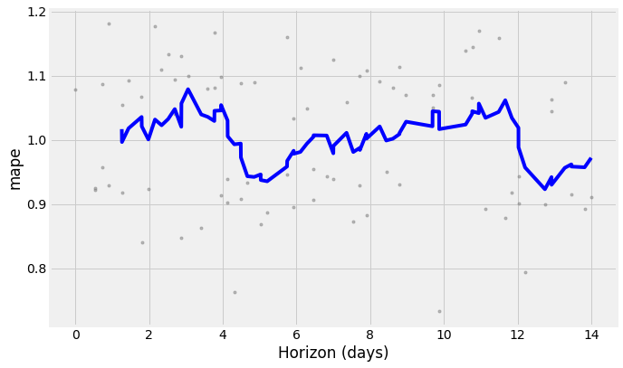

```python
fig3 = plot_cross_validation_metric(df_cv23, metric='mape')
```

### Test accuracy of final model mT_v3 with test data set

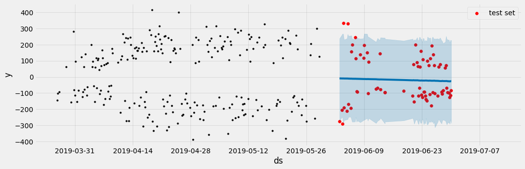

```python
# Plot the forecast with the actuals
f, ax = plt.subplots(1)
f.set_figheight(5)
f.set_figwidth(15)
ax.scatter(dataframe_test_N2Odry.index, dataframe_test_N2Odry['Flux'], color='r', label="test set")
ax.legend()
fig = mT_v3.plot(forecast_mT_v3, ax=ax)
```

### Set up final model mT_v3 (model resulting from hyperparameter tuning) to generate forecasts on the gas flux

#### Forecast for next 48 hours

```python
#future_48hT2     = mT_v3.make_future_dataframe(periods=48, freq='H', include_history = False)
#forecast_hoursT2 = mT_v3.predict(future_48hT2)

## Plot the forecast
#f, ax = plt.subplots(1)
#f.set_figheight(5)
#f.set_figwidth(15)
#fig = mT_v3.plot(forecast_hoursT2,ax=ax)
#plt.show()

## Plot the components of the model
#fig1 = mT_v3.plot_components(forecast_hoursT2)
#fig1.set_figwidth(20)
```

#### Forecast for next 2 weeks

```python
#future_2W2        = mT_v3.make_future_dataframe(periods=14, freq='D', include_history = False)
#forecast_2Wks2    = mT_v3.predict(future_2W2)

## Plot the forecast
#f, ax = plt.subplots(1)
#f.set_figheight(5)
#f.set_figwidth(15)
#fig = mT_v3.plot(forecast_2Wks2,ax=ax)
#plt.show()

## Plot the components of the model
#fig1 = mT_v3.plot_components(forecast_2Wks2)
#fig1.set_figwidth(20)
```

#### Forecast for next 2 months

```python
#### future_2M2        = mT_v1.make_future_dataframe(periods=30*2, freq='D', include_history = False)
#forecast_hours2M2 = mT_v3.predict(future_2M2)

## Plot the forecast
#f, ax = plt.subplots(1)
#f.set_figheight(5)
#f.set_figwidth(15)
#fig = mT_v3.plot(forecast_hours2M2,ax=ax)
#plt.show()

## Plot the components of the model
#fig1 = mT_v3.plot_components(forecast_hours2M2)
#fig1.set_figwidth(20)
```

#### Plot actual vs forecast (2 weeks) using tuned model mT_v3

```python
#df = df_N2Odry.reset_index().rename(columns={'DateTime': 'ds', 'Flux': 'y'})

## Plot the forecast with the actuals
#f1, ax = plt.subplots(1)
#f1.set_figheight(5)
#f1.set_figwidth(15)
#ax.scatter(df.ds, df['y'], color='r', label="test set")
#ax.legend()

#fig2 = mT_v3.plot(forecast_2Wks2, ax=ax)
```

```python
mT_v4 = Prophet(
    changepoint_prior_scale= 0.05,
    changepoint_range= 0.8,
    #n_changepoints= 125,
    seasonality_prior_scale= 1,
    seasonality_mode = 'multiplicative',
    growth = 'linear'
)

mT_v4.fit(df)
```

```
INFO:fbprophet:Disabling yearly seasonality. Run prophet with yearly_seasonality=True to override this.
```

```
<fbprophet.forecaster.Prophet at 0x7f82675eb610>
```

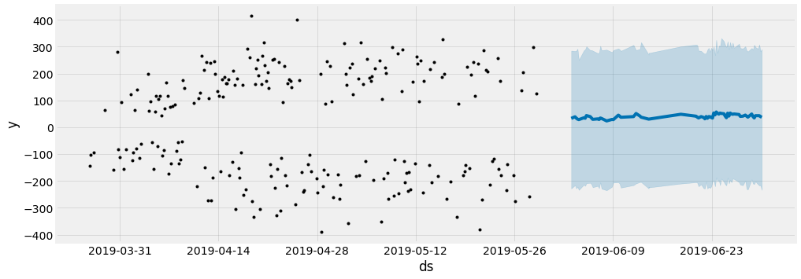

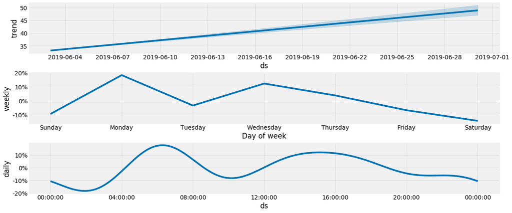

```python
forecast_mT_v4 = mT_v4.predict(df=dataframe_test_N2Odry.reset_index().rename(columns={'DateTime': 'ds'}))

fig21          = mT_v4.plot(forecast_mT_v4)
fig22          = mT_v4.plot_components(forecast_mT_v4)

fig21.set_figheight(5)
fig21.set_figwidth(15)

fig22.set_figheight(7)
fig22.set_figwidth(19)
```

```python
mape = mean_absolute_percentage_error(dataframe_test_N2Odry['Flux'],forecast_mT_v4['yhat'])
print("MAPE",round(mape,4))
```

```
MAPE 107.2347
```

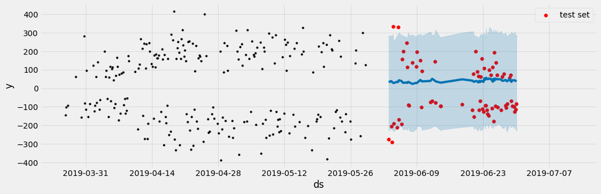

```python
# Plot the forecast with the actuals
f, ax = plt.subplots(1)
f.set_figheight(5)
f.set_figwidth(15)
ax.scatter(dataframe_test_N2Odry.index, dataframe_test_N2Odry['Flux'], color='r', label="test set")
ax.legend()
fig = mT_v4.plot(forecast_mT_v4, ax=ax)
```

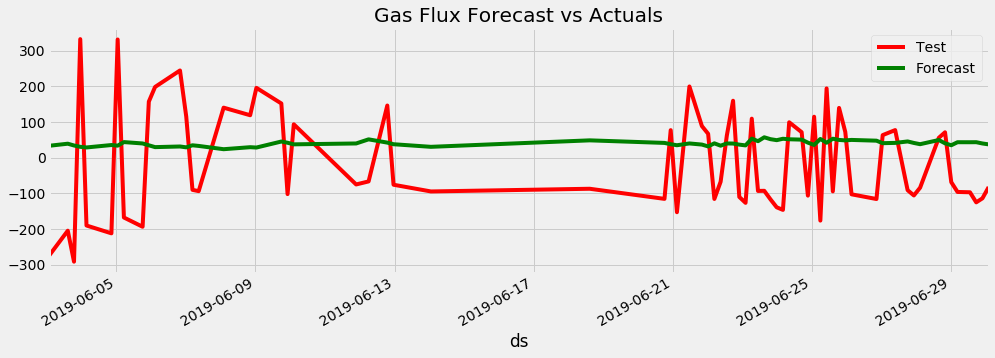

```python
df1=dataframe_test_N2Odry.reset_index().rename(columns={'DateTime': 'ds'})

f, ax = plt.subplots(figsize=(14,5))
f.set_figheight(5)
f.set_figwidth(15)

df1.plot(kind='line', x='ds', y='Flux', color='red', label='Test', ax=ax)
forecast_mT_v4.plot(kind='line',x='ds',y='yhat', color='green',label='Forecast', ax=ax)

plt.title('Gas Flux Forecast vs Actuals')
plt.show()
```

#### We can see from the above plot, that there is some gap in prediction.

So we need to optimize the model by adding other parameters like holidays, changepoints etc.

```python
# Resample from weekly to monthly
#co2_month = CO2.resample('MS').mean()

# Backfill any missing values
#co2_month.fillna(method='bfill', inplace=True)

#co2_month.head()
```

#### Notes about the different model parameters

##### Uncertainty in the trend

The biggest source of uncertainty in the forecast is the potential for future trend changes. Prophet is able to detect and fit these, but what trend changes should we expect moving forward? It’s impossible to know for sure, so we do the most reasonable thing we can, and we assume that the future will see similar trend changes as the history. In particular, we assume that the average frequency and magnitude of trend changes in the future will be the same as that which we observe in the history. We project these trend changes forward and by computing their distribution we obtain uncertainty intervals.

One property of this way of measuring uncertainty is that allowing higher flexibility in the rate, by increasing changepoint_prior_scale, will increase the forecast uncertainty. This is because if we model more rate changes in the history then we will expect more in the future, and makes the uncertainty intervals a useful indicator of overfitting.

the forecasted trend may vary between yhat_lower and yhat_upper

##### Uncertainty in seasonality

To get uncertainty in seasonality, you must do full Bayesian sampling. This is done using the parameter mcmc.samples (which defaults to 0).

### Hide code for printing/visualising purposes

```python
from IPython.display import HTML

HTML('''<script>
code_show=true;
function code_toggle() {
 if (code_show){
 $('div.input').hide();
 } else {
 $('div.input').show();
 }
 code_show = !code_show
}
$( document ).ready(code_toggle);
</script>
<form action="javascript:code_toggle()"><input type="submit" value="Click here to toggle on/off the raw code."></form>''')
```